# A social learning simulation in R

Rocky Brockway

07 December, 2023

# Introduction

The project develops a function, generateArtifactData (), to simulate the effects of social learning on continuous metric data in multiple assemblages over multiple generations. It is designed to generate testable expectations regarding several measures of variability: variation of the mean (VOM), average variation (AV), and variation of variation (VOV) (see Eerkens and Bettinger 2008). Although these measures were originally devised to address the difference between function and style, I show they are also useful to distinguish prestige biased social learning from guided variation. It should be noted, however, that differences in local conditions and a fitness landscape with multiple optima could potentially confound results. That is something that could be further explored with additional modeling, experimentation, and empirical data.

# A simple function

First, I provide a simple version of a function generateArtifactData designed to simulate both guided variation and prestige biased projectile point assemblages using continuous attributes. I use two measurements–length and width–but they could be any two continuous attributes. Having two attributes can facilitate comparison of different mean/sd combinations and covariance in the attributes.I have developed two additional versions of the function below. I favor version three, dubbed “a more realistic model” because I believe it most closely approximates the social learning process when indirect bias (e.g., prestige bias) is at play. It also accounts for the error inherent in the learning process and allows for intentional modification of artifact designs.

The simple function (below) generates *n* generations of *n* assemblages, each with *n* artifacts. A portion of each assemblage is created by prestigious individuals (Prestige), imitators (Prestige Learning), and non-imitators(Guided Variation), referred to as learning **scenarios**. The simulation utilizes the rnorm function in base R to create the data sets with initial means and standard deviations that are drawn from empirical data sets.

[interactive chart not shown]

[interactive chart not shown]

## Arguments within the generateArtifactData_simple function

- num_assemblages = number of assemblages from 1-n.
- num_artifacts = number of artifacts from 1-n in each assemblage and generation.
  - e.g., 10 artifacts x 5 assemblages x 2 generations = 100 artifacts total
- num_generations = number of generations from 1-n.
- initial_mean_length = number in mm - draw from empirical data - to initialize the model
- initial_mean_width = number in mm - draw from empirical data - to initialize the model
- initial_mean_length_sd = number in mm - draw from empirical data - to initialize the model
- initial_mean_width_sd = number in mm - draw from empirical data - to initialize the model
- prestige_proportion = the percentage (as a decimal) of the assemblage that represents the work of prestigious individuals
- prestige_learning probability = the likelihood (as a decimal) that individuals will engage in (prestige) biased social learning

```r
generateArtifactData_simple <- function(num_assemblages, num_artifacts, num_generations,
                                 initial_mean_length, initial_mean_width,
                                 initial_mean_length_sd, initial_mean_width_sd,
                                 prestige_proportion, prestige_learning_prob) {

  # Create empty data frames to store data
  df_combined_list <- list()

  # Initial values for prestige and guided variation
  prestige_mean_length <- initial_mean_length
  prestige_mean_width <- initial_mean_width
  prestige_length_sd <- initial_mean_length_sd
  prestige_width_sd <- initial_mean_width_sd

  guided_mean_length <- initial_mean_length
  guided_mean_width <- initial_mean_width
  guided_length_sd <- initial_mean_length_sd
  guided_width_sd <- initial_mean_width_sd

  for (generation in 1:num_generations) {
    for (assemblage in 1:num_assemblages) {
      # Generate prestige artifacts
      num_prestige <- round(num_artifacts * prestige_proportion)
      prestige_artifacts <- data.frame(
        Length = rnorm(num_prestige, mean = prestige_mean_length, sd = prestige_length_sd),
        Width = rnorm(num_prestige, mean = prestige_mean_width, sd = prestige_width_sd),
        Assemblage = rep(assemblage, times = num_prestige),
        Generation = rep(generation, times = num_prestige),
        Scenario = rep("Prestige", times = num_prestige)
      )

      # Generate artifacts influenced by prestige learning
      num_prestige_learning <- round(num_artifacts * prestige_learning_prob)
      prestige_learning_artifacts <- data.frame(
        Length = rnorm(num_prestige_learning, mean = prestige_mean_length, sd = prestige_length_sd),
        Width = rnorm(num_prestige_learning, mean = prestige_mean_width, sd = prestige_width_sd),
        Assemblage = rep(assemblage, times = num_prestige_learning),
        Generation = rep(generation, times = num_prestige_learning),
        Scenario = rep("Prestige Learning", times = num_prestige_learning)
      )

      # Generate artifacts influenced by guided variation
      num_guided <- num_artifacts - num_prestige - num_prestige_learning

       # Handle scenarios where num_guided is non-positive
      while (num_guided <= 0) {
        num_prestige <- num_prestige - 1
        num_prestige_learning <- num_prestige_learning - 1
        num_guided <- num_artifacts - num_prestige - num_prestige_learning
      }

      guided_artifacts <- data.frame(
        Length = rnorm(num_guided, mean = guided_mean_length, sd = guided_length_sd),
        Width = rnorm(num_guided, mean = guided_mean_width, sd = guided_width_sd),
        Assemblage = rep(assemblage, times = num_guided),
        Generation = rep(generation, times = num_guided),
        Scenario = rep("Guided Variation", times = num_guided)
      )

      # Combine the artifacts for this assemblage and add to the list
      generation_data <- rbind(prestige_artifacts, prestige_learning_artifacts, guided_artifacts)
      df_combined_list[[paste0("G", generation, "_A", assemblage)]] <- generation_data
    }

    # Update means and standard deviations for next generation
    prestige_mean_length <- mean(rbind(prestige_artifacts, prestige_learning_artifacts)$Length)
    prestige_mean_width <- mean(rbind(prestige_artifacts, prestige_learning_artifacts)$Width)
    prestige_length_sd <- sd(rbind(prestige_artifacts, prestige_learning_artifacts)$Length)
    prestige_width_sd <- sd(rbind(prestige_artifacts, prestige_learning_artifacts)$Width)

    guided_mean_length <- mean(guided_artifacts$Length)
    guided_mean_width <- mean(guided_artifacts$Width)
    guided_length_sd <- sd(guided_artifacts$Length)
    guided_width_sd <- sd(guided_artifacts$Width)
  }

  # Combine data frames from all generations and assemblages
  df_combined <- do.call(rbind, df_combined_list)

  return(df_combined)
}
```

## Calling the function

Note in the code chunk below, I have commented when argument values are based on empirical data. These data are included in the same repository as this document and are associated with ddig_pilot. Because this is a relatively simple function, we can easily include thousands of artifacts in each assemblage and simulate hundreds of generations. The set.seed function that precedes the function call ensures that the data are reproducible. Each time the function is called, it will produce the same “random” results.

```r
#Example call and head of data
set.seed(123)
artifact_data<-generateArtifactData_simple(
  num_assemblages = 5,
  num_artifacts = 1000,
  num_generations = 300,
  initial_mean_length = 38, #based on empirical data
  initial_mean_width = 21, #based on empirical data
  initial_mean_length_sd = 9, #based on empirical data
  initial_mean_width_sd = 3.75, #based on empirical data
  prestige_proportion = 0.15,
  prestige_learning_prob = 0.40)
```

## Function output

This is the head of our dataframe.

```r
#let's see a portion of the results
head(artifact_data, n=10)%>%
  gt()%>%
  tab_header(
    title = "generateArtifactData() Output",
    subtitle = "Artifact Data"
  )
```

generateArtifactData() Output

Artifact Data

| Length | Width | Assemblage | Generation | Scenario |
| --- | --- | --- | --- | --- |
| 32.95572 | 23.95402 | 1 | 1 | Prestige |
| 35.92840 | 23.88391 | 1 | 1 | Prestige |
| 52.02837 | 22.24576 | 1 | 1 | Prestige |
| 38.63458 | 17.21859 | 1 | 1 | Prestige |
| 39.16359 | 20.55205 | 1 | 1 | Prestige |
| 53.43558 | 19.94852 | 1 | 1 | Prestige |
| 42.14825 | 23.11121 | 1 | 1 | Prestige |
| 26.61445 | 19.60335 | 1 | 1 | Prestige |
| 31.81832 | 24.66365 | 1 | 1 | Prestige |
| 33.98904 | 19.59532 | 1 | 1 | Prestige |

## Examining our Function and Data Structure

Let’s take a look at how many observations we have in each category to ensure the data are structured appropriately.The results suggest the function is working properly.

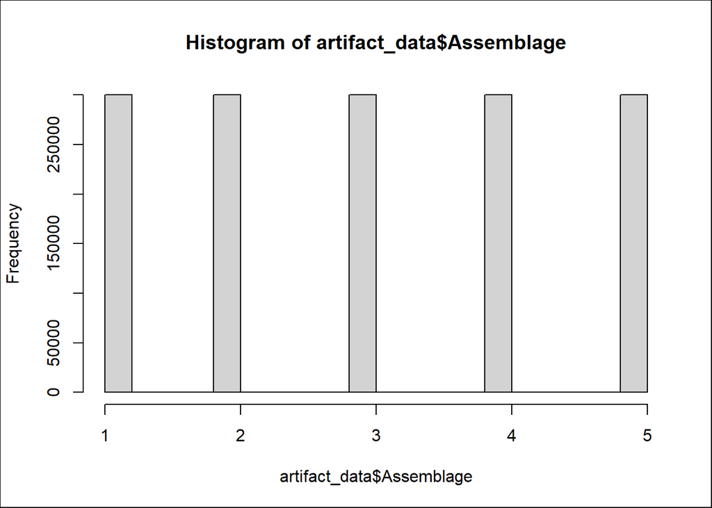

```r
#Count the number of observations by assemblage
hist(artifact_data$Assemblage)
box(col = "black", # Add box to plot
    which = "figure")
```

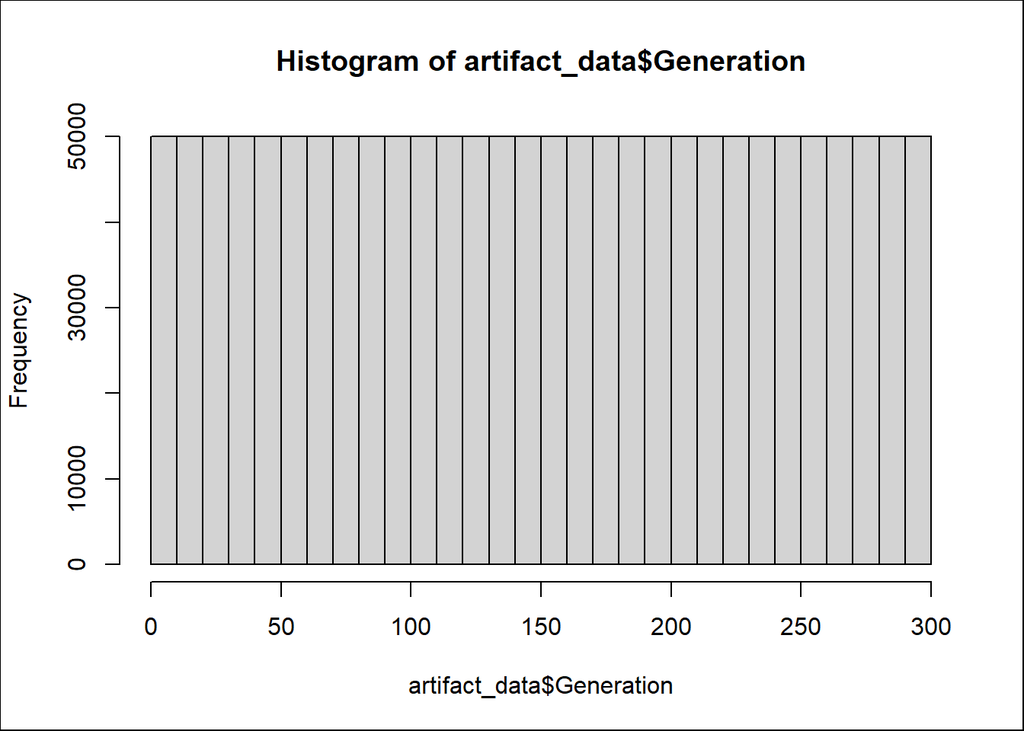

```r
#count the number of observations by generation
hist(artifact_data$Generation)
box(col = "black", # Add box to plot
    which = "figure")
```

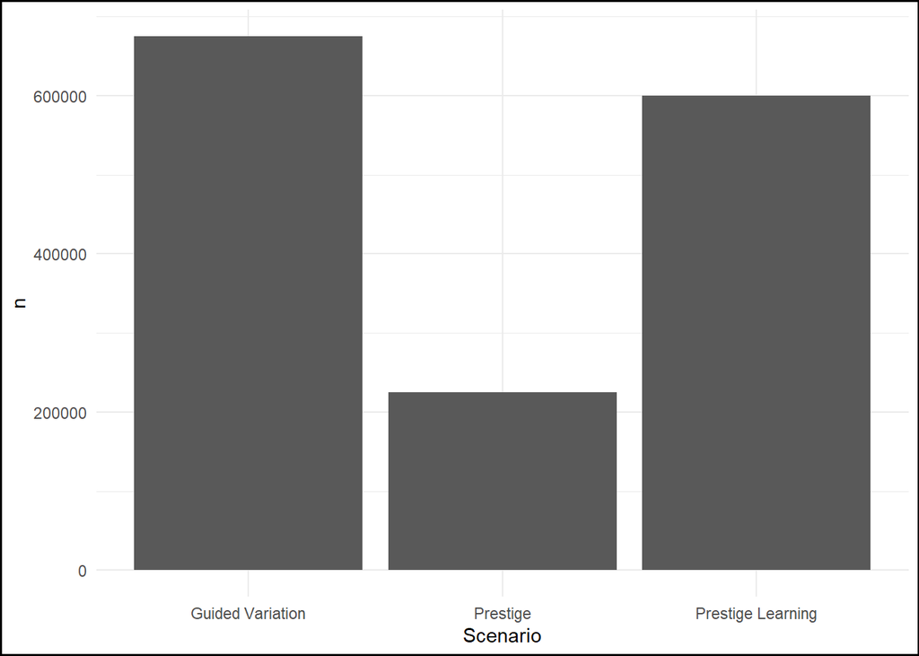

```r
#We can't use the hist() function on categorical data, but we can create a bar chart summarizing scenario observations
options(scipen = 999)#gets rid of scientific notation
artifact_data%>%
  group_by(Scenario)%>%
  summarize(n=n())%>%
    ggplot(aes(Scenario, n))+
    geom_bar(stat="identity")+
      theme_minimal()+
      theme(plot.background = element_rect(color ="black", linewidth = 1))
```

## Exploratory Data Analysis to Identify Trends

### Boxplots and density plots

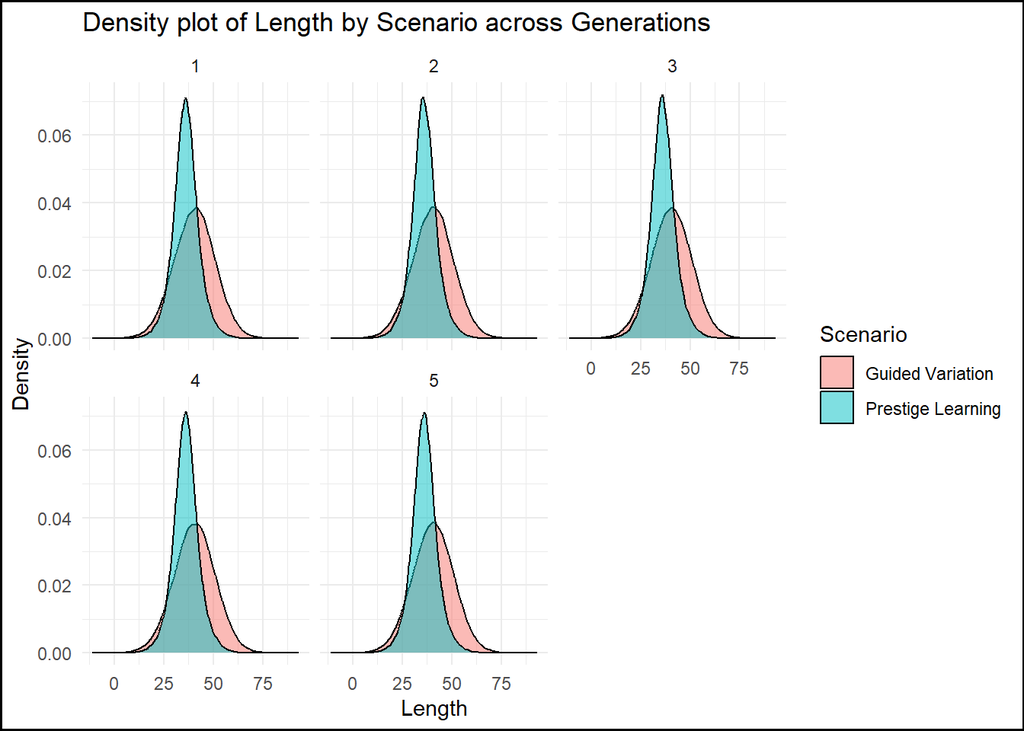

```r
artifact_data%>%
  filter(Scenario != "Prestige") %>%
  # Density plot for Length by Scenario across Generations
  ggplot(aes(x = Length, fill = Scenario)) +
  geom_density(alpha = 0.5) +
  facet_wrap(~ Assemblage) +
  theme_minimal() +
      theme(plot.background = element_rect(color ="black", linewidth = 1))+
  labs(title = "Density plot of Length by Scenario across Generations",
       y = "Density",
       x = "Length")
```

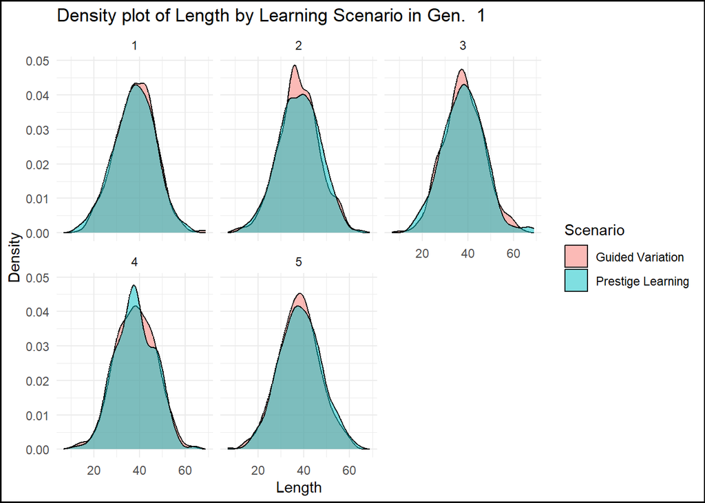

```r
artifact_data%>%
  filter(Scenario != "Prestige", Generation == min(Generation)) %>%
 # Density plot for Length by Scenario First Gen
  ggplot(aes(x = Length, fill = Scenario)) +
  geom_density(alpha = 0.5) +
  facet_wrap(~ Assemblage) +
  theme_minimal() +
      theme(plot.background = element_rect(color ="black", linewidth = 1))+
  labs(title = paste("Density plot of Length by Learning Scenario in Gen. ", min(artifact_data$Generation)),
       y = "Density",
       x = "Length")
```

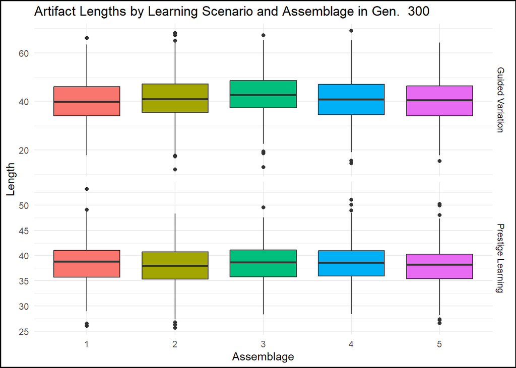

```r
artifact_data%>%
  filter(Scenario != "Prestige", Generation == max(Generation)) %>%
  ggplot(aes(x=factor(Assemblage), y = Length, fill=factor(Assemblage))) +
  geom_boxplot() +
  facet_grid(rows=vars(Scenario), scales="free")+
  labs(title = paste("Artifact Lengths by Learning Scenario and Assemblage in Gen. ", max(artifact_data$Generation)))+
  xlab("Assemblage")+
  theme_minimal()+
  theme(legend.position="none",
        plot.background = element_rect(color ="black", linewidth = 1))
```

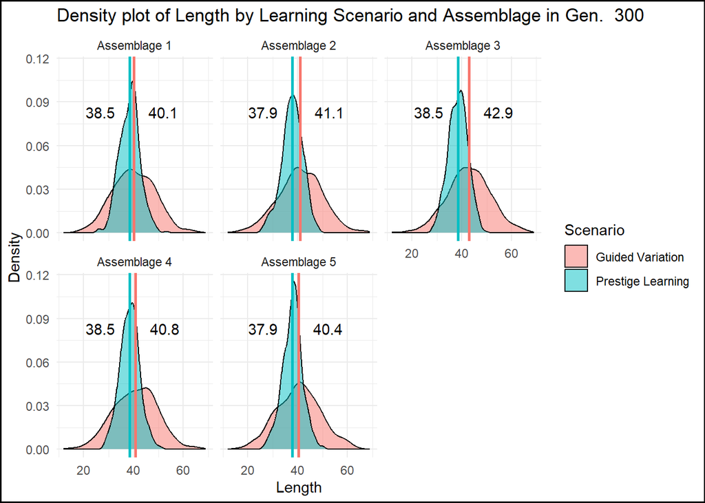

```r
means_vline<-artifact_data%>%
  filter(Scenario!= "Prestige", Generation==max(Generation))%>%
  group_by(Scenario,Assemblage)%>%
  summarise(mean=mean(Length))%>%
  mutate(side = if_else(Scenario == "Prestige Learning", 1.5, -0.5),
         label = round(mean, 1))  # Round to the nearest tenth

artifact_data %>%
  filter(Scenario != "Prestige", Generation == max(Generation)) %>%
  ggplot(aes(x = Length, fill = Scenario)) +
  geom_density(alpha = 0.5) +
  geom_vline(data = means_vline, aes(xintercept = mean, color = Scenario), linewidth=1) +
  geom_text(data = means_vline, aes(x = mean, y = 0.075, label = label, hjust = side), vjust = -0.5) +
  facet_wrap(~ Assemblage,
           labeller = labeller(Assemblage = function(x) paste("Assemblage", x))) +
  guides(color="none")+
theme_minimal() +
      theme(plot.background = element_rect(color ="black", linewidth = 1))+
  labs(title = paste("Density plot of Length by Learning Scenario and Assemblage in Gen. ", max(artifact_data$Generation)),
       y = "Density",
       x = "Length")
```

### Mean and standard deviation over time

The fact that prestige learning shows substantially less variation suggests the model may be useful because this is the traditional expectation for prestige-biased social learning. However, this may simply be confirmation bias and we should should use some additional exploratory data analysis to determine whether additional trends exist. One way is to identify the long-term trends over time in mean and standard deviation to see whether our trend holds true over time.

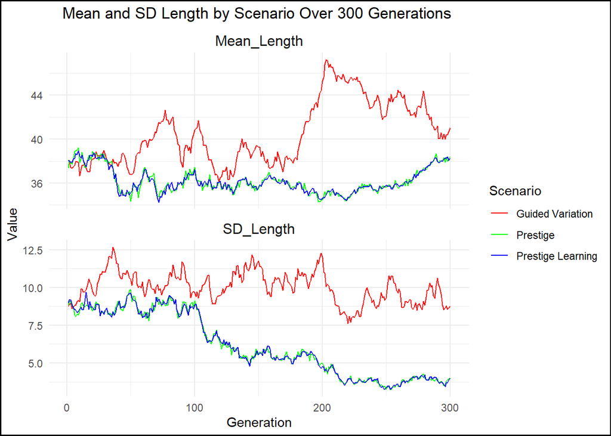

```r
# Calculate mean and standard deviation for each scenario and generation
generation_summary <- artifact_data %>%
  group_by(Scenario, Generation) %>%
  summarise(
    Mean_Length = mean(Length),
    SD_Length = sd(Length),
    .groups = 'drop'
  )

# Reshape the data to long format for plotting
generation_summary_long <- tidyr::pivot_longer(
  generation_summary,
  cols = c(Mean_Length, SD_Length),
  names_to = "Statistic",
  values_to = "Value"
)

# Plot the data by generation with separate facets for mean and SD
ggplot(generation_summary_long, aes(x = Generation, y = Value, color = Scenario)) +
  geom_line() +   # Add lines
  #geom_point(aes(shape = Scenario)) +     # Add points with shapes by Scenario
  facet_wrap(~ Statistic, scales = "free_y", ncol = 1) +  # Separate facets for mean and SD
  theme_minimal() +
  scale_color_manual(values = c("Guided Variation" = "red", "Prestige" = "green", "Prestige Learning" = "blue")) +
  scale_shape_manual(values = c("Guided Variation" = 17, "Prestige" = 15, "Prestige Learning" = 18)) +  # Shapes for scenarios
  labs(
    title = paste("Mean and SD Length by Scenario Over", max(generation_summary_long$Generation),"Generations "),
    x = "Generation",
    y = "Value",
    color = "Scenario",
    shape = "Scenario") +
  theme(strip.background = element_blank(),  # Remove facet strip background for a cleaner look
        strip.text.x = element_text(size = 12),  # Increase facet strip text size for readability
        plot.title = element_text(hjust = 0.5),
        plot.background = element_rect(color ="black", linewidth = 1))
```

## Exploring parameter space

To explore the possibility that function argument (i.e., parameter) values play a part in structuring the results, let’s develop a parameter grid - a dataframe with specific parameter combinations in each row. We can also develop the run_simulation function, which initiates the generateArtifactData_simple function and then filters the results based on the argument generation choice object.

### A function to help explore (run_simulation_simple)

```r
# Function to run simulation and return summarized results
run_simulation_simple <- function(num_artifacts,prestige_proportion, prestige_learning_prob, generation_choice = "all") {
  df <- generateArtifactData_simple(num_assemblages, num_artifacts, num_generations,
                                    initial_mean_length, initial_mean_width,
                                    initial_mean_length_sd, initial_mean_width_sd,
                                    prestige_proportion, prestige_learning_prob)

  # Filter for a specific generation if requested
  if (generation_choice != "all") {
    df <- df %>% filter(Generation == generation_choice)
  }

  # Summarize the results
  summary_df <- df %>%
    group_by(Scenario, Generation) %>%
    summarise(
      Total_Artifacts = n(),
      Num_Artifacts = num_artifacts,
      Mean_Length = mean(Length, na.rm = TRUE),# Calculate mean
      Mean_Width = mean(Width, na.rm = TRUE),# Calculate mean
      SD_Length = sd(Length, na.rm = TRUE),  # Calculate standard deviation
      SD_Width = sd(Width, na.rm = TRUE),  # Calculate standard deviation
      .groups = 'drop'
    )

  # If all generations were requested, collapse the summaries
  if (generation_choice == "all") {
    summary_df <- summary_df %>%
      group_by(Scenario) %>%
      summarise(
        Total_Artifacts = sum(Total_Artifacts),
        Num_Artifacts = num_artifacts,
        Mean_Length = mean(Mean_Length),
        Mean_Width = mean(Mean_Width),
        SD_Length = mean(SD_Length),
        SD_Width = mean(SD_Width),
        .groups = 'drop'
      )
  }

  return(summary_df)
}
```

### Calling the function

We will call the function with some parameters that are fixed and some that vary. The lapply function allows us to repeat our getArtifactData_simple function for each of the non-fixed parameters. In this example, the non-fixed parameters are the number of artifacts per assemblage, prestige proportion, and prestige learning probability. By varying the argument values, we attempt to identify relationships between the non-fixed parameters and the output. Here is a list of the parameters in this example:

- num_assemblages = 5
- num_generations = 300
- initial_mean_length = 38
- initial_mean_width = 21
- initial_mean_length_sd = 9
- initial_mean_width_sd = 3.75
- num_artifacts = 50, 100, 500, and 1000

prestige_proportion = 0.1, 0.2, 0.3, and 0.4

prestige_learning_prob_seq = 0.1, 0.2, 0.3, 0.4, and 0.5

```r
# Assume other parameters are fixed for this exploration
num_assemblages <- 5
num_generations <- 300
initial_mean_length <- 38
initial_mean_width <- 21
initial_mean_length_sd <- 9
initial_mean_width_sd <- 3.75

# Define the parameter ranges
num_artifacts_seq <- c(50, 100, 500, 1000)

prestige_proportion_seq <- seq(0.1, 0.4, by = 0.1)

prestige_learning_prob_seq <- seq(0.1, 0.5, by = 0.1)

# Create a grid of parameter combinations
param_grid <- expand.grid(num_artifacts = num_artifacts_seq,
                          prestige_proportion = prestige_proportion_seq,
                          prestige_learning_prob = prestige_learning_prob_seq)

# Choose the generation for which you want to run the simulation, or "all" for the mean across all generations
selected_generation <- 300  # "all" or a specific generation like 1

# Using lapply to run simulations for each parameter set in the grid
results_list <- lapply(1:nrow(param_grid), function(i) {
  run_simulation_simple(
    num_artifacts = param_grid$num_artifacts[i],
    prestige_proportion = param_grid$prestige_proportion[i],
    prestige_learning_prob = param_grid$prestige_learning_prob[i],
    generation_choice = selected_generation
  )
})


# Combine results into a single data frame
results_df <- do.call(rbind, results_list)
row.names(results_df) <- NULL

# Calculate how many times each parameter set is repeated based on the number of scenarios
num_scenarios <- length(unique(results_df$Scenario))

# Replicate the parameter values for the existing n rows of results_df
results_df$Prestige_Proportion <- rep(param_grid$prestige_proportion, each = 3)
results_df$Prestige_Learning_Prob <- rep(param_grid$prestige_learning_prob, each = 3)
```

```r
knitr::kable(head(results_df, 10),
             caption = paste0("Head of the output for run_simulation - Generation ", selected_generation),
             col.names = c("Scenario","Gen", "n", "n/Assem.", "x̄ Length", "x̄ Width", "σ Length", "σ Width","Prest. Prop.", "Prest. Learn."))
```

Head of the output for run_simulation - Generation 300

| Scenario | Gen | n | n/Assem. | x̄ Length | x̄ Width | σ Length | σ Width | Prest. Prop. | Prest. Learn. |
| --- | --- | --- | --- | --- | --- | --- | --- | --- | --- |
| Guided Variation | 300 | 200 | 50 | 51.64423 | 27.03036 | 0.0378435 | 0.4096636 | 0.1 | 0.1 |
| Prestige | 300 | 25 | 50 | 40.53575 | 26.62047 | 0.0000000 | 0.0002305 | 0.1 | 0.1 |
| Prestige Learning | 300 | 25 | 50 | 40.53575 | 26.62046 | 0.0000000 | 0.0003424 | 0.1 | 0.1 |
| Guided Variation | 300 | 400 | 100 | 42.23327 | 23.20504 | 0.3080524 | 0.6285294 | 0.1 | 0.1 |
| Prestige | 300 | 50 | 100 | 35.66554 | 22.96548 | 0.0037074 | 0.0028998 | 0.1 | 0.1 |
| Prestige Learning | 300 | 50 | 100 | 35.66434 | 22.96548 | 0.0037252 | 0.0033032 | 0.1 | 0.1 |
| Guided Variation | 300 | 2000 | 500 | 38.47710 | 19.10102 | 9.0943568 | 1.3037450 | 0.1 | 0.1 |
| Prestige | 300 | 250 | 500 | 33.72012 | 16.57320 | 4.1558753 | 1.8284642 | 0.1 | 0.1 |
| Prestige Learning | 300 | 250 | 500 | 33.85511 | 16.76813 | 4.4100672 | 1.7222862 | 0.1 | 0.1 |
| Guided Variation | 300 | 4000 | 1000 | 40.68251 | 21.90544 | 5.7166283 | 3.9582527 | 0.1 | 0.1 |

### Plot the results

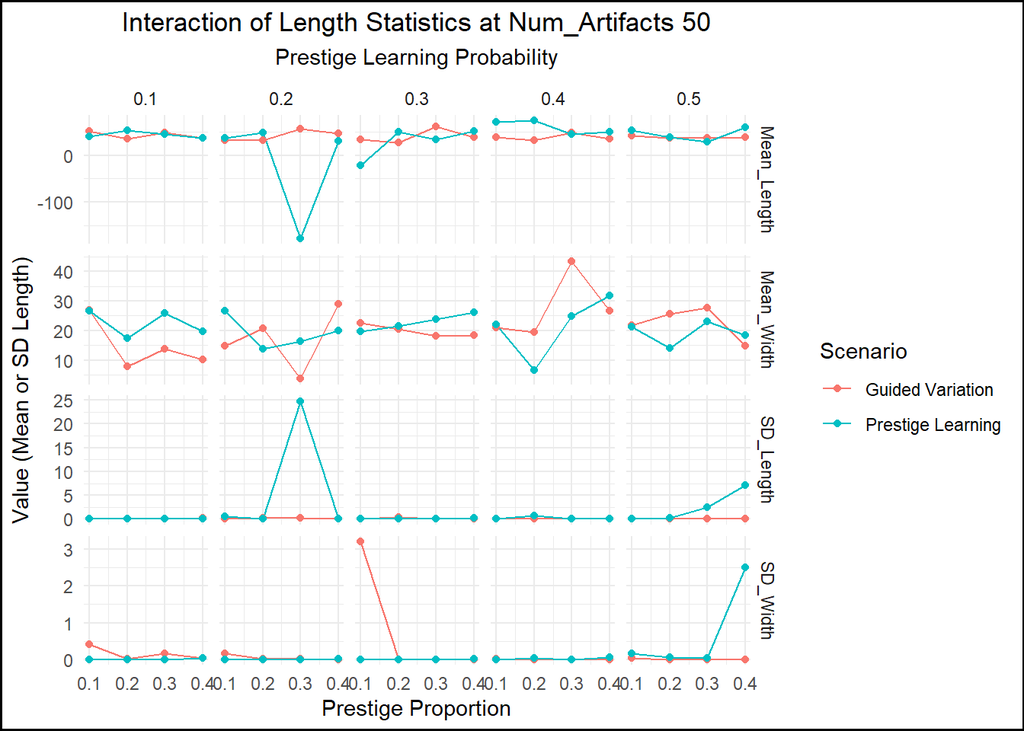

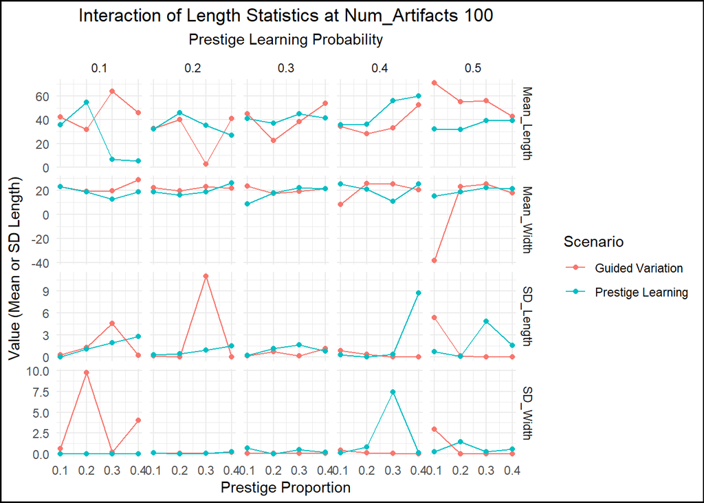

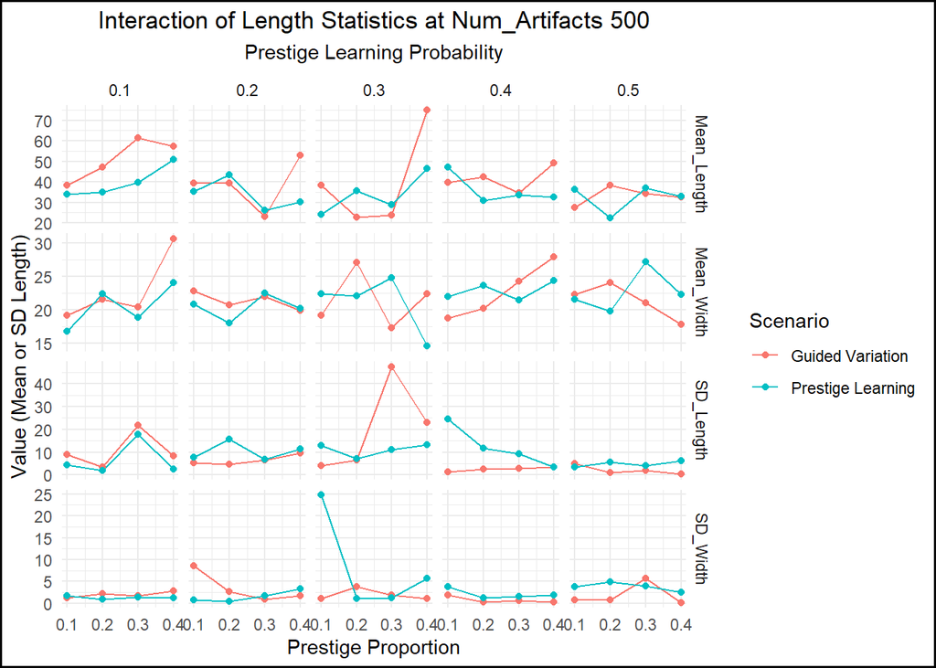

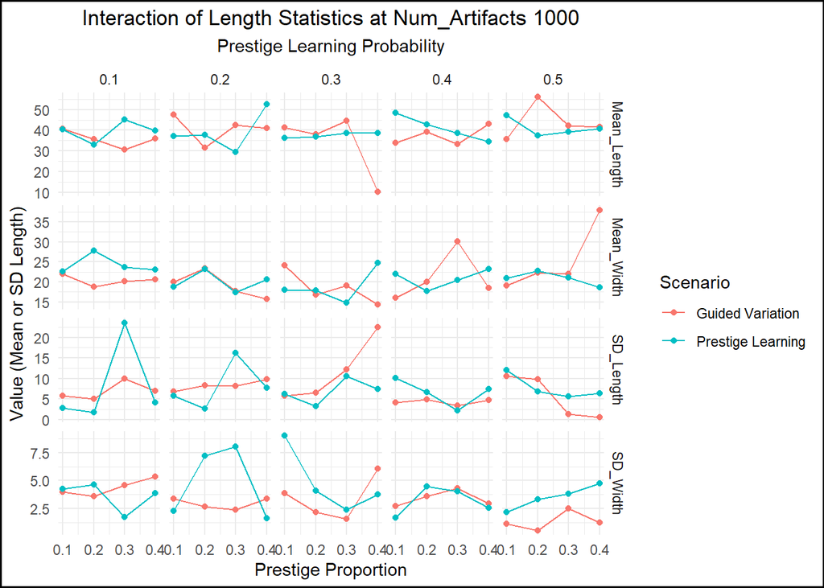

```r
# Transform results_df to a long format suitable for plotting with ggplot2
results_long <- tidyr::pivot_longer(
  results_df,
  cols = c("Mean_Length", "SD_Length", "Mean_Width", "SD_Width"),
  names_to = "Statistic",
  values_to = "Value")%>%
  filter(Scenario != "Prestige")

# Unique values of num_artifacts
unique_num_artifacts <- unique(results_long$Num_Artifacts)

# Create a plot for each unique value of num_artifacts
for(n in unique_num_artifacts) {
  # Filter the data for the current num_artifacts
  num_artifacts_data <- results_long %>% filter(Num_Artifacts == n)

  # Create the boxplot
  plot<-ggplot(num_artifacts_data, aes(x = Prestige_Proportion, y = Value, color = Scenario)) +
    geom_line() +
    geom_point()+
    facet_grid(Statistic~ Prestige_Learning_Prob, scales = "free_y") +
    theme_minimal() +
    labs(
      title = paste("Interaction of Length Statistics at Num_Artifacts", n),
      subtitle = "Prestige Learning Probability",
      x = "Prestige Proportion",
      y = "Value (Mean or SD Length)",
      fill = "Scenario"
    ) +
    theme(plot.title = element_text(hjust = 0.5),
        plot.subtitle = element_text(hjust = 0.5),
        plot.background = element_rect(color ="black", linewidth = 1))  # Ensure subtitle is centered

  plot(plot)
}
```

### Predictive significance of the parameters

The plot is interesting, but it’s not immediately clear whether there is a significant relationship between mean or standard deviation and the other parameters. We can call a correlation plot using ggpairs that gives correlation values, density plots, and scatter plots of the results from our run simulation function. There are very few significant correlations and those that are significant are not terribly helpful. However, mean width and prestige proportion do appear to be significantly correlated as noted by the *.

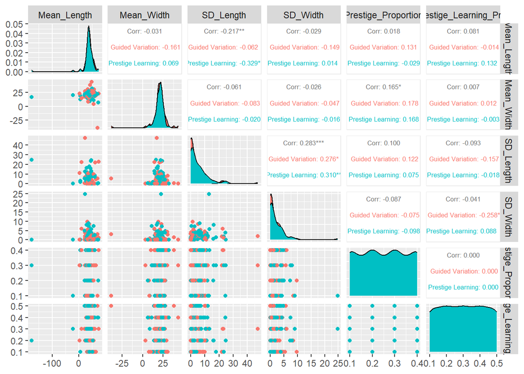

```r
ggpairs(results_df[results_df$Scenario != "Prestige",], columns = 5:10, ggplot2::aes(color=Scenario), upper = list(continuous = wrap("cor", size = 2.25)))
```

```r
# Fit a linear model
results_df<- results_df%>%
  filter(Scenario != "Prestige")


lm_mean_l<- lm(Mean_Length ~ Prestige_Proportion + Prestige_Learning_Prob+Scenario, data = results_df)

lm_sd_l<-lm(SD_Length ~ Prestige_Proportion + Prestige_Learning_Prob+Scenario, data = results_df)


# Check the model summaries
summary(lm_mean_l)
```

```
##
## Call:
## lm(formula = Mean_Length ~ Prestige_Proportion + Prestige_Learning_Prob +
##     Scenario, data = results_df)
##
## Residuals:
##      Min       1Q   Median       3Q      Max
## -211.861   -5.726    0.813    7.929   36.173
##
## Coefficients:
##                           Estimate Std. Error t value      Pr(>|t|)
## (Intercept)                 35.744      5.649   6.328 0.00000000251 ***
## Prestige_Proportion          3.289     14.898   0.221         0.826
## Prestige_Learning_Prob      12.062     11.778   1.024         0.307
## ScenarioPrestige Learning   -4.268      3.331  -1.281         0.202
## ---
## Signif. codes:  0 '***' 0.001 '**' 0.01 '*' 0.05 '.' 0.1 ' ' 1
##
## Residual standard error: 21.07 on 156 degrees of freedom
## Multiple R-squared:  0.01725,    Adjusted R-squared:  -0.001647
## F-statistic: 0.9128 on 3 and 156 DF,  p-value: 0.4363
```

```r
summary(lm_sd_l)
```

```
##
## Call:
## lm(formula = SD_Length ~ Prestige_Proportion + Prestige_Learning_Prob +
##     Scenario, data = results_df)
##
## Residuals:
##    Min     1Q Median     3Q    Max
## -6.670 -4.072 -2.275  2.219 42.877
##
## Coefficients:
##                           Estimate Std. Error t value Pr(>|t|)
## (Intercept)                 4.1126     1.7348   2.371    0.019 *
## Prestige_Proportion         5.7950     4.5755   1.267    0.207
## Prestige_Learning_Prob     -4.2676     3.6172  -1.180    0.240
## ScenarioPrestige Learning   0.6667     1.0231   0.652    0.516
## ---
## Signif. codes:  0 '***' 0.001 '**' 0.01 '*' 0.05 '.' 0.1 ' ' 1
##
## Residual standard error: 6.471 on 156 degrees of freedom
## Multiple R-squared:  0.02146,    Adjusted R-squared:  0.002639
## F-statistic:  1.14 on 3 and 156 DF,  p-value: 0.3347
```

```r
lm_mean_l2<- lm(Mean_Length ~ Prestige_Proportion * Prestige_Learning_Prob*Scenario, data = results_df)

lm_sd_l2<-lm(SD_Length ~ Prestige_Proportion * Prestige_Learning_Prob*Scenario, data = results_df)

summary(lm_mean_l2)
```

```
##
## Call:
## lm(formula = Mean_Length ~ Prestige_Proportion * Prestige_Learning_Prob *
##     Scenario, data = results_df)
##
## Residuals:
##      Min       1Q   Median       3Q      Max
## -209.479   -4.662    0.289    8.527   34.875
##
## Coefficients:
##                                                                      Estimate
## (Intercept)                                                             32.27
## Prestige_Proportion                                                     33.02
## Prestige_Learning_Prob                                                  14.96
## ScenarioPrestige Learning                                                5.98
## Prestige_Proportion:Prestige_Learning_Prob                             -64.39
## Prestige_Proportion:ScenarioPrestige Learning                          -72.66
## Prestige_Learning_Prob:ScenarioPrestige Learning                       -16.80
## Prestige_Proportion:Prestige_Learning_Prob:ScenarioPrestige Learning   172.75
##                                                                      Std. Error
## (Intercept)                                                               13.60
## Prestige_Proportion                                                       49.66
## Prestige_Learning_Prob                                                    41.01
## ScenarioPrestige Learning                                                 19.23
## Prestige_Proportion:Prestige_Learning_Prob                               149.74
## Prestige_Proportion:ScenarioPrestige Learning                             70.23
## Prestige_Learning_Prob:ScenarioPrestige Learning                          57.99
## Prestige_Proportion:Prestige_Learning_Prob:ScenarioPrestige Learning     211.76
##                                                                      t value
## (Intercept)                                                            2.373
## Prestige_Proportion                                                    0.665
## Prestige_Learning_Prob                                                 0.365
## ScenarioPrestige Learning                                              0.311
## Prestige_Proportion:Prestige_Learning_Prob                            -0.430
## Prestige_Proportion:ScenarioPrestige Learning                         -1.035
## Prestige_Learning_Prob:ScenarioPrestige Learning                      -0.290
## Prestige_Proportion:Prestige_Learning_Prob:ScenarioPrestige Learning   0.816
##                                                                      Pr(>|t|)
## (Intercept)                                                            0.0189 *
## Prestige_Proportion                                                    0.5071
## Prestige_Learning_Prob                                                 0.7157
## ScenarioPrestige Learning                                              0.7563
## Prestige_Proportion:Prestige_Learning_Prob                             0.6678
## Prestige_Proportion:ScenarioPrestige Learning                          0.3025
## Prestige_Learning_Prob:ScenarioPrestige Learning                       0.7725
## Prestige_Proportion:Prestige_Learning_Prob:ScenarioPrestige Learning   0.4159
## ---
## Signif. codes:  0 '***' 0.001 '**' 0.01 '*' 0.05 '.' 0.1 ' ' 1
##
## Residual standard error: 21.18 on 152 degrees of freedom
## Multiple R-squared:  0.03275,    Adjusted R-squared:  -0.0118
## F-statistic: 0.7352 on 7 and 152 DF,  p-value: 0.6424
```

```r
summary(lm_sd_l2)
```

```
##
## Call:
## lm(formula = SD_Length ~ Prestige_Proportion * Prestige_Learning_Prob *
##     Scenario, data = results_df)
##
## Residuals:
##    Min     1Q Median     3Q    Max
## -8.437 -3.867 -1.971  2.152 42.784
##
## Coefficients:
##                                                                      Estimate
## (Intercept)                                                            0.5063
## Prestige_Proportion                                                   24.4241
## Prestige_Learning_Prob                                                 6.1925
## ScenarioPrestige Learning                                              0.7646
## Prestige_Proportion:Prestige_Learning_Prob                           -55.8541
## Prestige_Proportion:ScenarioPrestige Learning                         -8.7999
## Prestige_Learning_Prob:ScenarioPrestige Learning                       2.7952
## Prestige_Proportion:Prestige_Learning_Prob:ScenarioPrestige Learning  16.8467
##                                                                      Std. Error
## (Intercept)                                                              4.1651
## Prestige_Proportion                                                     15.2089
## Prestige_Learning_Prob                                                  12.5584
## ScenarioPrestige Learning                                                5.8904
## Prestige_Proportion:Prestige_Learning_Prob                              45.8567
## Prestige_Proportion:ScenarioPrestige Learning                           21.5087
## Prestige_Learning_Prob:ScenarioPrestige Learning                        17.7602
## Prestige_Proportion:Prestige_Learning_Prob:ScenarioPrestige Learning    64.8512
##                                                                      t value
## (Intercept)                                                            0.122
## Prestige_Proportion                                                    1.606
## Prestige_Learning_Prob                                                 0.493
## ScenarioPrestige Learning                                              0.130
## Prestige_Proportion:Prestige_Learning_Prob                            -1.218
## Prestige_Proportion:ScenarioPrestige Learning                         -0.409
## Prestige_Learning_Prob:ScenarioPrestige Learning                       0.157
## Prestige_Proportion:Prestige_Learning_Prob:ScenarioPrestige Learning   0.260
##                                                                      Pr(>|t|)
## (Intercept)                                                             0.903
## Prestige_Proportion                                                     0.110
## Prestige_Learning_Prob                                                  0.623
## ScenarioPrestige Learning                                               0.897
## Prestige_Proportion:Prestige_Learning_Prob                              0.225
## Prestige_Proportion:ScenarioPrestige Learning                           0.683
## Prestige_Learning_Prob:ScenarioPrestige Learning                        0.875
## Prestige_Proportion:Prestige_Learning_Prob:ScenarioPrestige Learning    0.795
##
## Residual standard error: 6.485 on 152 degrees of freedom
## Multiple R-squared:  0.0423, Adjusted R-squared:  -0.001806
## F-statistic: 0.959 on 7 and 152 DF,  p-value: 0.4633
```

```r
results_df$Scenario<-factor(results_df$Scenario)

summary(glm(Scenario~Prestige_Proportion+Prestige_Learning_Prob+Mean_Length+SD_Length+Mean_Width+SD_Width, data=results_df, family = "binomial"))
```

```
##
## Call:
## glm(formula = Scenario ~ Prestige_Proportion + Prestige_Learning_Prob +
##     Mean_Length + SD_Length + Mean_Width + SD_Width, family = "binomial",
##     data = results_df)
##
## Coefficients:
##                         Estimate Std. Error z value Pr(>|z|)
## (Intercept)             0.146867   0.817446   0.180    0.857
## Prestige_Proportion     0.112684   1.465087   0.077    0.939
## Prestige_Learning_Prob  0.181030   1.131683   0.160    0.873
## Mean_Length            -0.011772   0.010584  -1.112    0.266
## SD_Length               0.003025   0.027007   0.112    0.911
## Mean_Width              0.004536   0.024113   0.188    0.851
## SD_Width                0.065767   0.068572   0.959    0.338
##
## (Dispersion parameter for binomial family taken to be 1)
##
##     Null deviance: 221.81  on 159  degrees of freedom
## Residual deviance: 218.66  on 153  degrees of freedom
## AIC: 232.66
##
## Number of Fisher Scoring iterations: 4
```

## Conclusions about the simple model

Creating the simple model has been instructive. However, the output thus far lack predictive power and given the lack of significant relationships, we can forgo developing other measures of variation that might be helpful. The model also lacks the dynamics that would make for a more realistic model of social learning. For example, rather than completely reshuffling the metrics in each generation by using the rnorm function without regard to assemblage, a more realistic model could either reshuffle the metrics using the mean and standard deviation of each assemblage or it would simply copy the previous generation and make slight alterations in measurements based on a human error term. This would more closely approximate transmission from one generation to another. The rnorm function is problematic with artifact measurements because it sometimes generates negative measurements or measurements that would be impractical because of functional constraints. Thus, a more realistic model would also have min and max values to keep the measurements “on the rails”. A more realistic model might also try to account for differences in prestige, which would skew the amount of copies made of specific artifacts, and it might also have parameters to help model intentional modification like we would expect in guided variation. With these thoughts in mind, the next section presents just such a model.

# A more nuanced function

This version of the function was an intermediate step towards the more realistic model and is retained in this document for now in case I want to come back to it. It includes a number of arguments that help to more adequately model the differences between guided variation and prestige biased social learning. The assemblages are generated using the rnorm_bounded() function that puts guardrails on the data. I used ranges from empirical data to assign these min and max values. I added an option to fluctuate the standard deviation when generating data for guided variation to account for individual learning. There is also an option to adjust the standard deviation for prestige learning to account for the possibility that there is less variation inherent to that process - an empirical questions that needs to be explored but is not explored below. For this model:

- Guided variation uses initial means and fluctuating standard deviations (based on initial values) within a bounded random normal distribution.
- Prestige biased learning uses the mean attribute for the previous generation’s prestige artifacts but keeps the standard deviation set at the beginning of the simulation.

The model dynamics can be adjusted in subsequent iterations to consider how emergent patterns in guided variation might differ if they were structured more like prestige bias but without using prestigious individuals as models or whether patterns in prestige learning might differ if the SD was also drawn from the subsequent generation.

### Arguments within the generateArtifactData_nuanced function

- num_assemblages = number of assemblages from 1-n.
- num_artifacts = number of artifacts from 1-n in each assemblage and generation.
  - e.g., 10 artifacts x 5 assemblages x 2 generations = 100 artifacts total
- num_generations = number of generations from 1-n.
- initial_mean_length = number in mm - draw from empirical data - to initialize the model
- initial_mean_width = number in mm - draw from empirical data - to initialize the model
- initial_mean_length_sd = number in mm, also emprical
- initial_mean_width_sd = number in mm, also emprical
- prestige_proportion = the percentage (as a decimal) of the assemblage that represents the work of prestigious individuals
- prestige_learning probability = the likelihood (as a decimal) that individuals will engage in (prestige) biased social learning
- min_length = minimum allowable length in mm, empirical
- max_length = maximum allowable length in mm, empirical
- min_width = minimum allowable width in mm, empirical
- max_width = maximum allowable width in mm, empirical
- guided_sd_fluct_len = fluctuations in sd that represent innovation, expressed as a percentage (decimal) of the initial sd
- guided_sd_fluct_wid = fluctuations in sd that represent innovation, expressed as a percentage (decimal) of the initial sd
- prestige_sd_len = standard deviation expressed as a percentage (decimal) of initial sd for prestige biased artifacts
- prestige_sd_wid = standard deviation expressed as a percentage (decimal) of iniital sd for prestige biased artifacts

```r
generateArtifactData_nuanced <- function(num_assemblages, num_artifacts, num_generations,
                                 initial_mean_length, initial_mean_width,
                                 initial_mean_length_sd, initial_mean_width_sd,
                                 prestige_proportion, prestige_learning_prob,
                                 min_length, max_length, min_width, max_width,
                                 guided_sd_fluct_len, guided_sd_fluct_wid,
                                 prestige_sd_len, prestige_sd_wid) {

  # Create empty list to store dataframes
  df_combined_list <- list()

  # Initial values for prestige and guided variation
  # replicate elements - rep(x,times)- helps with for loops - creates a vector with the mean value for each assemblage
  assemblage_prestige_mean_lengths <- rep(initial_mean_length, num_assemblages)
  assemblage_prestige_mean_widths <- rep(initial_mean_width, num_assemblages)

  #sets the sd fluctuations for guided variation
  guided_length_sd_fluctuation <- guided_sd_fluct_len * initial_mean_length_sd
  guided_width_sd_fluctuation <- guided_sd_fluct_wid * initial_mean_width_sd

  #sets the prestige sd values
  prestige_learning_length_SD <- prestige_sd_len * initial_mean_length_sd
  prestige_learning_width_SD <- prestige_sd_wid * initial_mean_width_sd

  #nested for loops that generate the data
  #for each generation and assemblage, create prestige artifacts as a proportion of the total in a 5 variable dataframe.
  #measurement variables are generated using rnorm_bounded(n, mean = , sd = , max =, min =) function
  #other variables are generated using rep function
  for (generation in 1:num_generations) {
    for (assemblage in 1:num_assemblages) {
      # Generate prestige artifacts
      num_prestige <- round(num_artifacts * prestige_proportion)
      prestige_artifacts <- data.frame(
        Length = rnorm_bounded(num_prestige, mean = assemblage_prestige_mean_lengths[assemblage], sd = initial_mean_length_sd,
                               min = min_length, max = max_length),
        Width = rnorm_bounded(num_prestige, mean = assemblage_prestige_mean_widths[assemblage], sd = initial_mean_width_sd,
                      min=min_width, max=max_width),
        Assemblage = rep(assemblage, times = num_prestige),
        Generation = rep(generation, times = num_prestige),
        Scenario = rep("Prestige", times = num_prestige)
      )


      # Generate artifacts influenced by prestige learning
      num_prestige_learning <- round(num_artifacts * prestige_learning_prob)
      prestige_learning_artifacts <- data.frame(
        Length = rnorm_bounded(num_prestige_learning, mean = assemblage_prestige_mean_lengths[assemblage],
                       sd = prestige_learning_length_SD, min = min_length, max = max_length),
        Width = rnorm_bounded(num_prestige_learning, mean = assemblage_prestige_mean_widths[assemblage],
                      sd = prestige_learning_width_SD, min = min_width, max = max_width),
        Assemblage = rep(assemblage, times = num_prestige_learning),
        Generation = rep(generation, times = num_prestige_learning),
        Scenario = rep("Prestige Learning", times = num_prestige_learning)
      )


      # Generate artifacts influenced by guided variation
      num_guided <- num_artifacts - num_prestige - num_prestige_learning

      # Handle scenarios where num_guided is non-positive - mainly necessary if exploring parameter space
      while (num_guided <= 0) {
        num_prestige <- num_prestige - 1
        num_prestige_learning <- num_prestige_learning - 1
        num_guided <- num_artifacts - num_prestige - num_prestige_learning
      }

      # Introduce slight fluctuations in SD for guided variation
      guided_length_sd <- initial_mean_length_sd + runif(1, -guided_length_sd_fluctuation, guided_length_sd_fluctuation)
      guided_width_sd <- initial_mean_width_sd + runif(1, -guided_width_sd_fluctuation, guided_width_sd_fluctuation)

      guided_artifacts <- data.frame(
        Length = rnorm_bounded(num_guided, mean = initial_mean_length, sd = guided_length_sd, min = min_length, max = max_length),
        Width = rnorm_bounded(num_guided, mean = initial_mean_width, sd = guided_width_sd,min = min_width, max = max_width),
        Assemblage = rep(assemblage, times = num_guided),
        Generation = rep(generation, times = num_guided),
        Scenario = rep("Guided Variation", times = num_guided)
      )


      # Combine the artifacts for this assemblage and add to the list
      generation_data <- rbind(prestige_artifacts, prestige_learning_artifacts, guided_artifacts)
      df_combined_list[[paste0("G", generation, "_A", assemblage)]] <- generation_data
    }

    # Update prestige means for next generation for each assemblage
    for (assemblage in 1:num_assemblages) {
      current_assemblage_data <- df_combined_list[[paste0("G", generation, "_A", assemblage)]]
      prestige_data <- current_assemblage_data[current_assemblage_data$Scenario == "Prestige", ]
      assemblage_prestige_mean_lengths[assemblage] <- mean(prestige_data$Length)
      assemblage_prestige_mean_widths[assemblage] <- mean(prestige_data$Width)
    }
  }

  # Combine data frames from all generations and assemblages
  df_combined <- do.call(rbind, df_combined_list)

  return(df_combined)
}
```

```r
# Calling the function with specified parameter values
set.seed(123) # make reproducible
artifact_data <- generateArtifactData_nuanced(
  num_assemblages = 5,
  num_artifacts = 100,
  num_generations = 300,
  initial_mean_length = 38, #based on empirical data
  initial_mean_width = 21, #based on empirical data
  initial_mean_length_sd = 9, #based on empirical data
  initial_mean_width_sd = 3.75, #based on empirical data
  prestige_proportion = 0.15,
  prestige_learning_prob = 0.6,
  min_length = 19.5,  # Minimum length constraint based on empirical data
  max_length = 69,  # Maximum length constraint based on empirical data
  min_width = 12.3,   # Minimum width constraint based on empirical data
  max_width = 32,    # Maximum width constraint based on empirical data
  guided_sd_fluct_len = 0.005,
  guided_sd_fluct_wid = 0.005,
  prestige_sd_len = 1.0,
  prestige_sd_wid = 1.0
)

# Viewing the first few rows of the generated data
head(artifact_data)
```

```
##           Length    Width Assemblage Generation Scenario
## G1_A1.1 33.32387 25.79164          1          1 Prestige
## G1_A1.2 45.32969 18.50997          1          1 Prestige
## G1_A1.3 36.19743 14.89391          1          1 Prestige
## G1_A1.4 48.80760 19.39377          1          1 Prestige
## G1_A1.5 52.09846 27.29402          1          1 Prestige
## G1_A1.6 24.34098 25.58300          1          1 Prestige
```

# A more realistic model

Finally, I created a model which is likely the most realistic of the three.

In this model:

1. The first generation of artifacts is initialized using a bounded random normal distribution informed by empirical data
2. Subsequent generations:

```
* are initialized by copying the previous generation directly to simulate vertical transmission within guided variation and prestige groups

* guided variation and prestige artifacts are slightly modified to simulate human error in the production process; the modification is modeled as a bounded random normal distribution and each artifact measurement is multiplied by the error term to calculate the standard deviation

* a normalized influence variable is assigned and calculated for all prestigious individuals based on an exponential distribution controlled by a rate (prestige strength)

* prestige learners are assigned a prestige artifact to copy in proportion to the prestige strength and these artifacts are modified by assigning a standard deviation that is the artifact dimension multiplied by the error term

* all artifacts are then subject to intentional modification where a portion of the assemblage is generated again with the bounded random normal function and the initial mean, sd, min, and max parameters

* the results are added to a list and at the end of the simulation everything is combined into a single dataframe
```

[interactive chart not shown]

## Arguments within the generateArtifactData function

- num_assemblages = number of assemblages from 1-n.
- num_artifacts = number of artifacts from 1-n in each assemblage and generation.
  - e.g., 10 artifacts x 5 assemblages x 2 generations = 100 artifacts total
- num_generations = number of generations from 1-n.
- initial_mean_length = number in mm - draw from empirical data - to initialize the model
- initial_mean_width = number in mm - draw from empirical data - to initialize the model
- initial_mean_length_sd = number in mm, also emprical
- initial_mean_width_sd = number in mm, also emprical
- prestige_proportion = the percentage (as a decimal) of the assemblage that represents the work of prestigious individuals
- prestige_learning probability = the likelihood (as a decimal) that individuals will engage in (prestige) biased social learning
- min_length = minimum allowable length in mm, empirical
- max_length = maximum allowable length in mm, empirical
- min_width = minimum allowable width in mm, empirical
- max_width = maximum allowable width in mm, empirical
- human_error_sd = the percent (as a decimal) of human error inherent in artifact production; see Eerkens and Bettinger 2001
- guided_modification_prob = the likelihood (as a decimal) that individuals will modify their artifact, rather than copying from parents Modeled as a random normal distribution
- prestige_modification_prob = the likelihood (as a decimal) that individuals will modify their artifact, rather than copying from parents Modeled as a random normal distribution. Generally the same as Guided Variation, but could be different.
- prestige_learning_modification_prob = the likelihood (as a decimal) that individuals will modify their artifact, rather than copying from a prestigious individual. Modeled as a random normal distribution. Generally set to 0.
- prestige_strength = used to affect the influence of prestigious individuals (modeled as an exponential distribution) within a given generation and assemblage. This is just the rate argument in the rexp function.

we can visualize the effect of different rate values in the plots below:

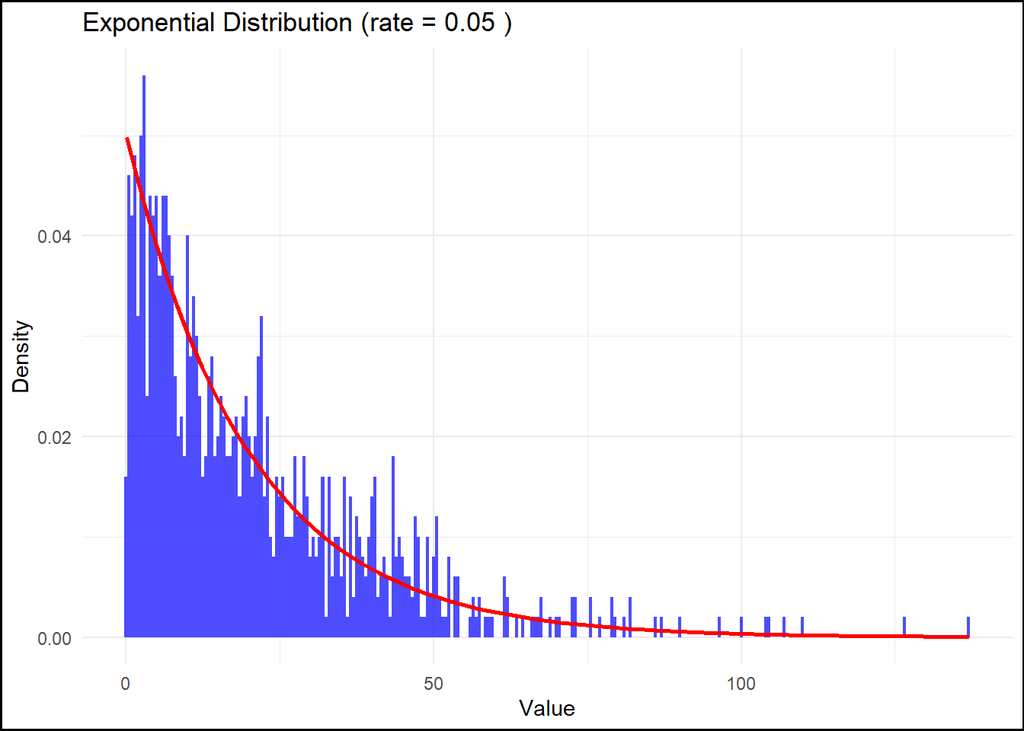

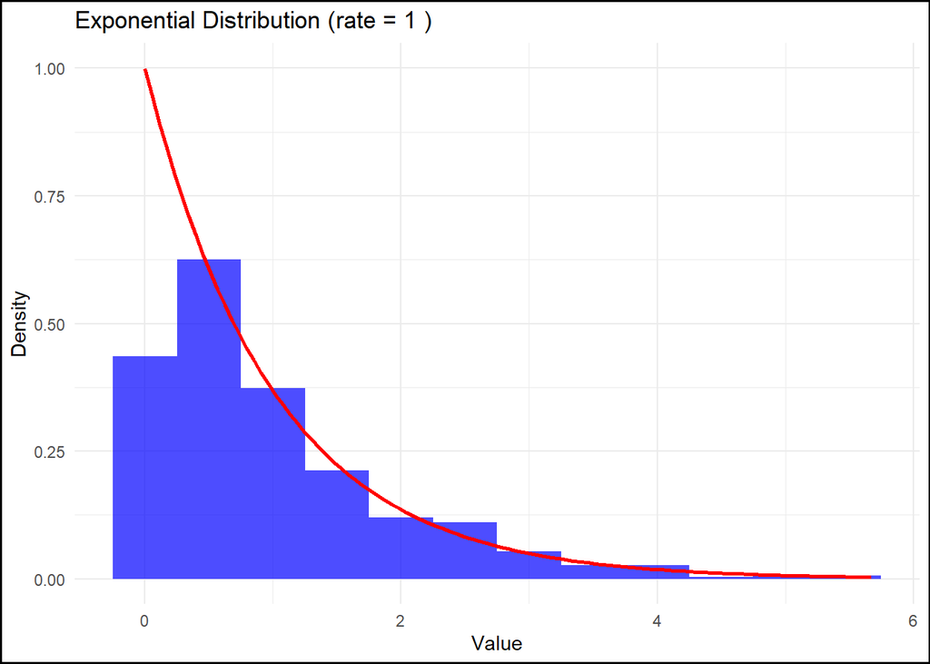

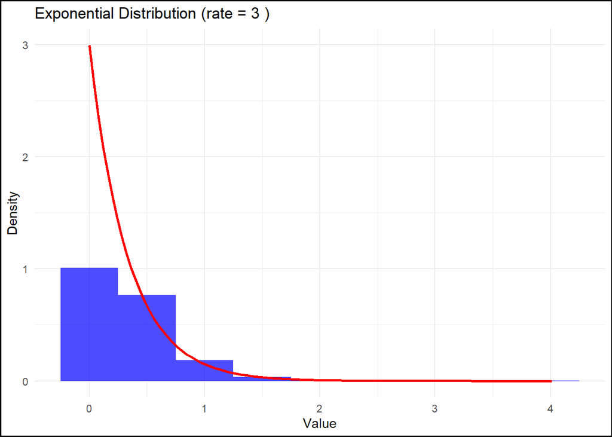

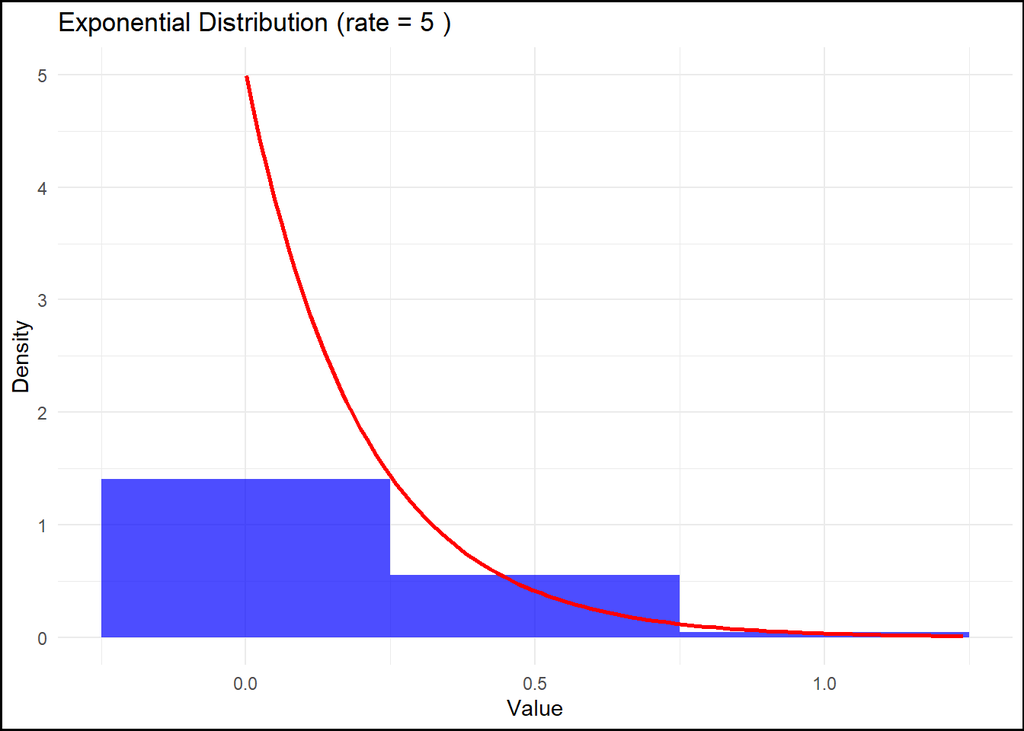

```r
generateArtifactData <- function(num_assemblages, num_artifacts, num_generations,
                                 initial_mean_length, initial_mean_width,
                                 initial_mean_length_sd, initial_mean_width_sd,
                                 prestige_proportion, prestige_learning_prob,
                                 min_length, max_length, min_width, max_width, human_error_sd,
                                 guided_modification_prob, prestige_modification_prob,
                                 prestige_learning_modification_prob, prestige_strength) {

    # Calculate the number of artifacts in each scenario
    num_prestige <- round(num_artifacts * prestige_proportion)
    num_prestige_learning <- round(num_artifacts * prestige_learning_prob)
    num_guided <- num_artifacts - num_prestige - num_prestige_learning

# create an empty list to store dataframes
df_combined_list<-list()

# Initialize the first generation artifacts for each assemblage
for (assemblage in 1:num_assemblages){
  #prestige artifacts
  prestige_data<-data.frame(
    Scenario=rep("Prestige",num_prestige),
    Generation=rep(1,times=num_prestige),
    Assemblage=rep(assemblage,times=num_prestige),
    Length = rnorm_bounded(num_prestige,
                           mean = initial_mean_length,
                           sd = initial_mean_length_sd,
                           min = min_length,
                           max = max_length),
    Width = rnorm_bounded(num_prestige,
                          mean = initial_mean_width,
                          sd = initial_mean_width_sd,
                          min=min_width,
                          max=max_width)
  )

# prestige learning artifacts
  prestige_learning_data<-data.frame(
    Scenario=rep("Prestige Learning",num_prestige_learning),
    Generation=rep(1,num_prestige_learning),
    Assemblage=rep(assemblage,times=num_prestige_learning),
    Length = rnorm_bounded(num_prestige_learning,
                           mean = initial_mean_length,
                           sd = initial_mean_length_sd,
                           min = min_length,
                           max = max_length),
    Width = rnorm_bounded(num_prestige_learning,
                          mean = initial_mean_width,
                          sd = initial_mean_width_sd,
                          min=min_width,
                          max=max_width)
  )

  #guided variation artifacts
  guided_data<-data.frame(
    Scenario=rep("Guided Variation",num_guided),
    Generation=rep(1,num_guided),
    Assemblage=rep(assemblage, times=num_guided),
    Length = rnorm_bounded(num_guided,
                           mean = initial_mean_length,
                           sd = initial_mean_length_sd,
                           min = min_length,
                           max = max_length),
    Width = rnorm_bounded(num_guided,
                          mean = initial_mean_width,
                          sd = initial_mean_width_sd,
                          min=min_width,
                          max=max_width)
  )

  # put the data into the list after binding the rows together
  df_combined_list <- c(df_combined_list, list(rbind(prestige_data, prestige_learning_data, guided_data)))

  # Combine data frames from all assemblages of the first generation
  df_combined_list<-list(list_rbind(df_combined_list))

}

# Check if only one generation is needed
if (num_generations == 1) {
  artifact_data <- df_combined_list[[1]]
    return(artifact_data)
}

for (generation in 2:num_generations) {
    # Get artifacts from the most recent generation only
    previous_gen_artifacts <- df_combined_list[[length(df_combined_list)]]

################################################################################################
############## Apply HUMAN ERROR to all of the length and width measurements#####################
#################################################################################################

    for (i in 1:nrow(previous_gen_artifacts)) {
        previous_gen_artifacts$Length[i] <- rnorm_bounded(1,
                                                          mean = previous_gen_artifacts$Length[i],
                                                          sd = previous_gen_artifacts$Length[i] * human_error_sd,
                                                          min = min_length,
                                                          max = max_length)

        previous_gen_artifacts$Width[i] <- rnorm_bounded(1,
                                                         mean = previous_gen_artifacts$Width[i],
                                                         sd = previous_gen_artifacts$Width[i] * human_error_sd,
                                                         min = min_width,
                                                         max = max_width)
    }

#################################################################################################
############## Apply PRESTIGE INTENTIONAL MODIFICATIONS #########################################
#################################################################################################

        prestige_indices <- data.frame(
          Length = rnorm_bounded(ceiling(length(rownames(previous_gen_artifacts)
                                        [previous_gen_artifacts$Scenario == "Prestige"])*
                                          prestige_modification_prob),
                           mean = initial_mean_length,
                           sd = initial_mean_length_sd,
                           min = min_length,
                           max = max_length),

          Width = rnorm_bounded(ceiling(length(rownames(previous_gen_artifacts)
                                       [previous_gen_artifacts$Scenario == "Prestige"])*
                                         prestige_modification_prob),
                          mean = initial_mean_width,
                          sd = initial_mean_width_sd,
                          min=min_width,
                          max=max_width),
```

```r
          row.names=as.numeric(sample(rownames(previous_gen_artifacts)
                                      [previous_gen_artifacts$Scenario == "Prestige"],
                                     size = ceiling(num_prestige*num_assemblages*prestige_modification_prob))))



        #create a new dataframe for PRESTIGE mods
       prestige_mods_index<-as.numeric(rownames(prestige_indices))

        #insert the mods into the dataframe
        previous_gen_artifacts$Length[prestige_mods_index]<-prestige_indices$Length
        previous_gen_artifacts$Width[prestige_mods_index]<-prestige_indices$Width

############################################################################################################
############### Loop over each assemblage to assign INFLUENCE SCORES and perform copying####################
############################################################################################################

    for (assemblage in 1:num_assemblages) {
        # Get indices of Prestige and Prestige Learning artifacts within the assemblage
        prestige_indices <- which(previous_gen_artifacts$Scenario == "Prestige" &
                                  previous_gen_artifacts$Assemblage == assemblage)
        prestige_learning_indices <- which(previous_gen_artifacts$Scenario == "Prestige Learning" &
                                           previous_gen_artifacts$Assemblage == assemblage)

        if(length(prestige_indices) > 0 && length(prestige_learning_indices) > 0) {
            # Generate influence scores based on exponential distribution
            influence_scores <- rexp(length(prestige_indices), rate = prestige_strength)

            # Normalize these probabilities to sum to 1
            influence_probabilities <- influence_scores / sum(influence_scores)

            # Sample from the Prestige artifacts according to influence probabilities, with replacement
            sampled_indices <- sample(prestige_indices, size = length(prestige_learning_indices), replace = TRUE, prob = influence_probabilities)

            # Copy the attributes from Prestige to Prestige Learning artifacts
            for (i in seq_along(prestige_learning_indices)) {
                copied_index <- sampled_indices[i]
                prestige_learning_index <- prestige_learning_indices[i]

                # Copy the Length and Width from the selected Prestige artifact with human error
                previous_gen_artifacts$Length[prestige_learning_index] <- rnorm_bounded(1,
                                                                                        mean = previous_gen_artifacts$Length[copied_index],
                                                                                        sd = previous_gen_artifacts$Length[copied_index] * human_error_sd,
                                                                                        min = min_length,
                                                                                        max = max_length)
                previous_gen_artifacts$Width[prestige_learning_index] <- rnorm_bounded(1,
                                                                                       mean = previous_gen_artifacts$Width[copied_index],
                                                                                       sd = previous_gen_artifacts$Width[copied_index] * human_error_sd,
                                                                                       min = min_width,
                                                                                       max = max_width)
            }
        }
    }

#################################################################################################
############## Apply PRESTIGE LEARNING AND GUIDED VARIATION INTENTIONAL MODS#####################
#################################################################################################

#Prestige Learning artifact mods - if there is some portion of prestige learning that decide to deviate purposefully
        prestige_learning_indices <- data.frame(
          Length = rnorm_bounded(ceiling(length(rownames(previous_gen_artifacts)
                                        [previous_gen_artifacts$Scenario == "Prestige Learning"])*
                                   prestige_learning_modification_prob),
                           mean = initial_mean_length,
                           sd = initial_mean_length_sd,
                           min = min_length,
                           max = max_length),

          Width = rnorm_bounded(ceiling(length(rownames(previous_gen_artifacts)
                                       [previous_gen_artifacts$Scenario == "Prestige Learning"])*
                                  prestige_learning_modification_prob),
                          mean = initial_mean_width,
                          sd = initial_mean_width_sd,
                          min=min_width,
                          max=max_width),

          row.names=as.numeric(sample(rownames(previous_gen_artifacts)
                                      [previous_gen_artifacts$Scenario == "Prestige Learning"],
                                     size = ceiling(num_prestige_learning*num_assemblages*prestige_learning_modification_prob))))

#Guided Variation artifact mods
        guided_indices <- data.frame(
          Length = rnorm_bounded(ceiling(length(rownames(previous_gen_artifacts)
                                        [previous_gen_artifacts$Scenario == "Guided Variation"])*
                                   guided_modification_prob),
                           mean = initial_mean_length,
                           sd = initial_mean_length_sd,
                           min = min_length,
                           max = max_length),

          Width = rnorm_bounded(ceiling(length(rownames(previous_gen_artifacts)
                                       [previous_gen_artifacts$Scenario == "Guided Variation"])*
                                   guided_modification_prob),
                          mean = initial_mean_width,
                          sd = initial_mean_width_sd,
                          min=min_width,
                          max=max_width),
          row.names= as.numeric(sample(rownames(previous_gen_artifacts)
                                            [previous_gen_artifacts$Scenario == "Guided Variation"],
                                            size = ceiling(num_guided*num_assemblages*guided_modification_prob))))
        #create a new dataframe for PRESTIGE LEARNING AND GUIDED VARIATION mods
        artifact_mods_df<- rbind(prestige_learning_indices, guided_indices)
        artifact_mods_index<-as.numeric(rownames(artifact_mods_df))
```

```r
        #insert the mods into the dataframe
        previous_gen_artifacts$Length[artifact_mods_index]<-artifact_mods_df$Length
        previous_gen_artifacts$Width[artifact_mods_index]<-artifact_mods_df$Width

        #rename to current gen
        current_gen_artifacts<-previous_gen_artifacts

        # Set the Generation column in the new data frame
        current_gen_artifacts$Generation <- generation

        #Combine the new data with the existing data in df_combined_list
        df_combined_list[[length(df_combined_list)+1]]<-current_gen_artifacts
}

# Combine data frames from all generations and assemblages
artifact_data <- list_rbind(df_combined_list)

return(artifact_data)

}
```

## Call the function

```r
# Calling the function with specified parameter values
set.seed(123) # make reproducible
artifact_data <- generateArtifactData(
  num_assemblages = 5,
  num_artifacts = 500,
  num_generations = 100,
  initial_mean_length = 38, #based on empirical data
  initial_mean_width = 21, #based on empirical data
  initial_mean_length_sd = 9, #based on empirical data
  initial_mean_width_sd = 3.75, #based on empirical data
  prestige_proportion = 0.15,
  prestige_learning_prob = 0.40,
  min_length = 19.5,  # Minimum length constraint based on empirical data
  max_length = 69,  # Maximum length constraint based on empirical data
  min_width = 12.3,   # Minimum width constraint based on empirical data
  max_width = 32,    # Maximum width constraint based on empirical data
  human_error_sd = 0.02, #Eerkens and Bettinger 2001 say about 2% for the likely limits of human copying ability
  guided_modification_prob=.5,
  prestige_modification_prob=.5,
  prestige_learning_modification_prob=0.00,
  prestige_strength=10)
```

## Output

Here is the head of our dataframe presented as a table using the gt package.

Head of generateArtifactData() Output

Artifact Data

| Scenario | Generation | Assemblage | Length | Width |
| --- | --- | --- | --- | --- |
| Prestige | 1 | 1 | 33.32387 | 18.20061 |
| Prestige | 1 | 1 | 45.32969 | 19.90837 |
| Prestige | 1 | 1 | 36.19743 | 22.10310 |
| Prestige | 1 | 1 | 48.80760 | 19.63371 |
| Prestige | 1 | 1 | 52.09846 | 16.59360 |
| Prestige | 1 | 1 | 24.34098 | 18.48132 |

## Examining our Function and Data Structure

Let’s take a look at how many observations we have in each category to ensure the data are structured appropriately.These all suggest the function is working properly and generating the right data in the right proportions.

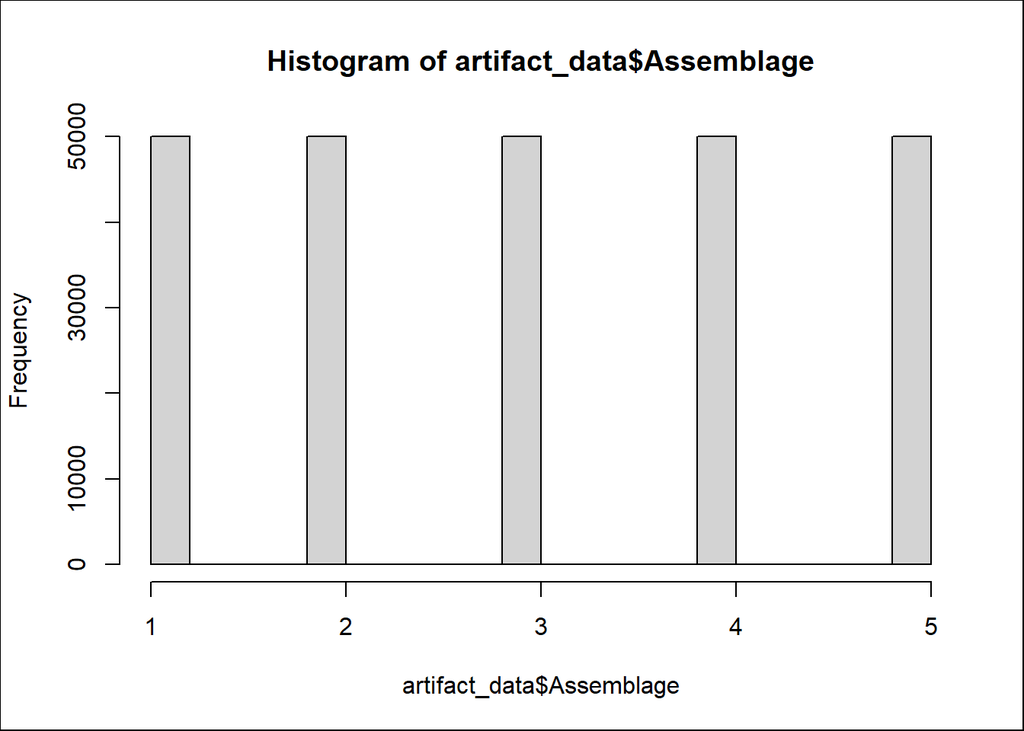

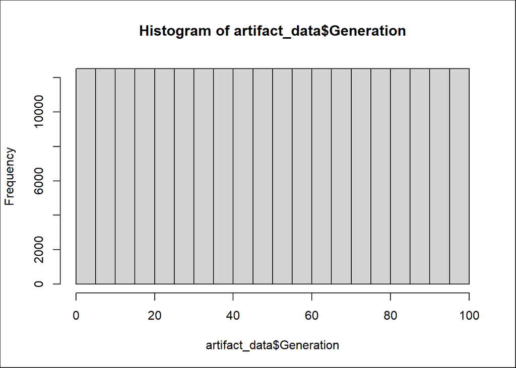

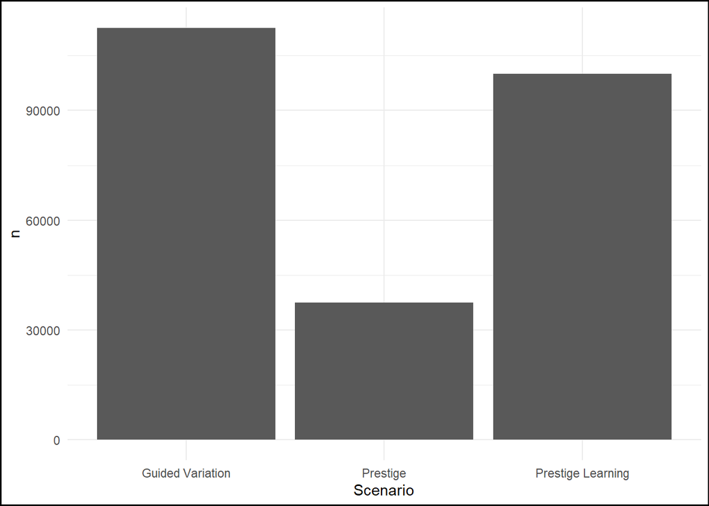

## Exploratory Data Analysis to Identify Trends

First we can take a look at all observations in artifact data. In the case of 5 assemblages with 500 artifacts each for 100 generations, that’s 250,000 observations. However, first we will filter out the prestige artifacts (i.e., artifacts created by prestigious individuals) because our main goal is to compare prestige biased social learning with guided variation. The artifacts created by prestigious individuals are likely a small portion of the assemblage compared with artifacts made by imitators if there is a strong tendency towards prestige bias. However, it should be noted that the arguments in genereateArtifactData () do allow us to adjust the proportion of prestige, prestige learning, and guided variation artifacts in the data set.

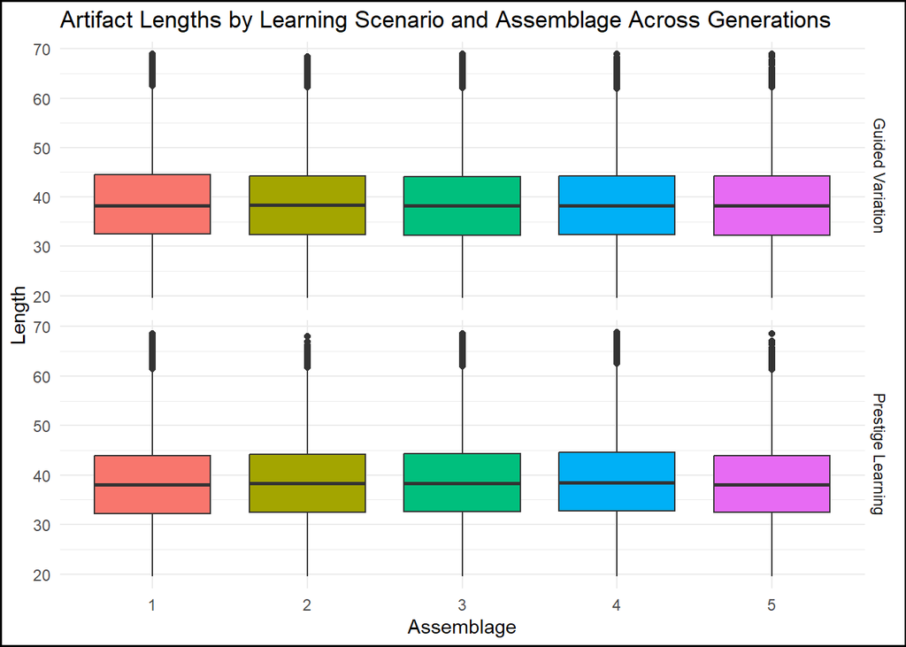

```r
# Filter out only Prestige Learning and Guided Variation scenarios
filtered_data <- artifact_data[artifact_data$Scenario %in% c("Prestige Learning", "Guided Variation"), ]

#Boxplot for Length by scenario across generations
ggplot(filtered_data, aes(x=factor(Assemblage), y = Length, fill=factor(Assemblage))) +
  geom_boxplot() +
  facet_grid(rows=vars(Scenario), scales="free")+
  labs(title = "Artifact Lengths by Learning Scenario and Assemblage Across Generations")+
  xlab("Assemblage")+
  theme_minimal()+
  theme(legend.position="none",
        plot.background = element_rect(color ="black", linewidth = 1))
```

```r
### Let's filter the data and examine within generations
  #here we can see a lot more variability between assemblages and scenarios

Gen_Filter<-100


filtered_data2 <- filtered_data[filtered_data$Generation==Gen_Filter,]

means_vline <- artifact_data %>%
  filter(Scenario != "Prestige", Generation == max(Generation)) %>%
  group_by(Scenario, Assemblage) %>%
  summarise(mean = mean(Length)) %>%
  arrange(Assemblage, mean) %>%
  group_by(Assemblage) %>%
  mutate(side = if_else(row_number() == 1, 1.5, -0.5),
         label = round(mean, 1))
```

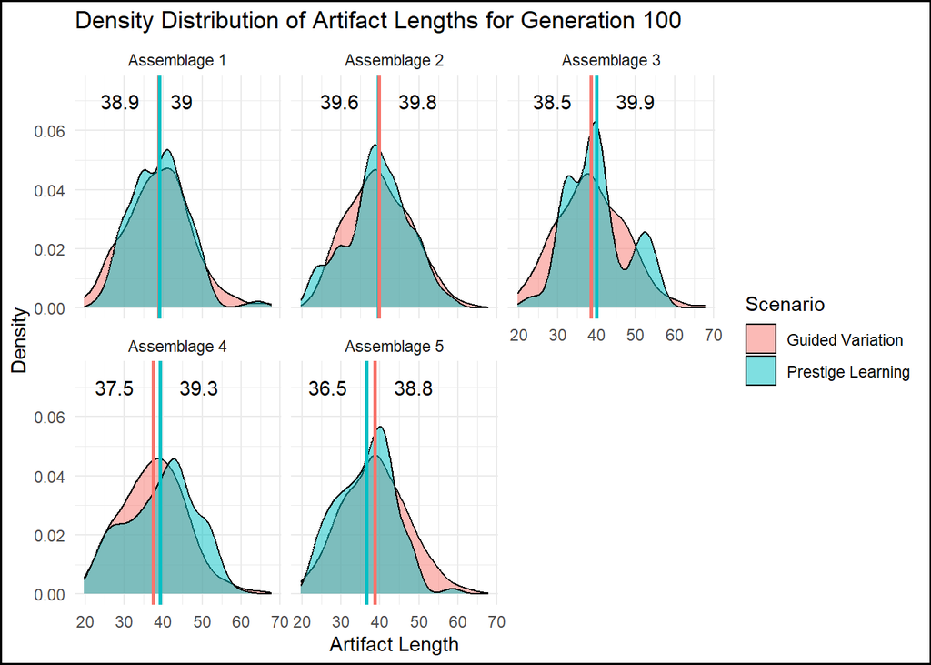

```r
# Create density distribution plots
ggplot(filtered_data2, aes(x = Length, fill = Scenario)) +
  geom_density(alpha = 0.5) +
  geom_vline(data = means_vline, aes(xintercept = mean, color = Scenario), linewidth=1) +
  geom_text(data = means_vline, aes(x = mean, y = 0.075, label = label, hjust = side), vjust = 1.5) +
  facet_wrap(~ Assemblage,
           labeller = labeller(Assemblage = function(x) paste("Assemblage", x))) +
  guides(color="none")+
  labs(title = paste("Density Distribution of Artifact Lengths for Generation", Gen_Filter),
       x = "Artifact Length",
       y = "Density") +
  theme_minimal()+
      theme(plot.background = element_rect(color ="black", linewidth = 1))
```

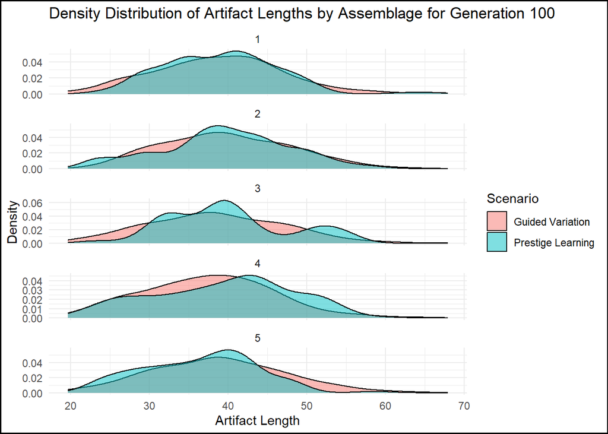

```r
# Create stacked density distribution plots-length
ggplot(filtered_data2, aes(x = Length, fill = Scenario)) +
  geom_density(alpha = 0.5, position = "identity") +
  facet_wrap(~Assemblage, scales = "free_y", ncol = 1) +
  labs(title = paste("Density Distribution of Artifact Lengths by Assemblage for Generation", Gen_Filter),
       x = "Artifact Length",
       y = "Density",
       fill = "Scenario") +
  theme_minimal()+
      theme(plot.background = element_rect(color ="black", linewidth = 1))
```

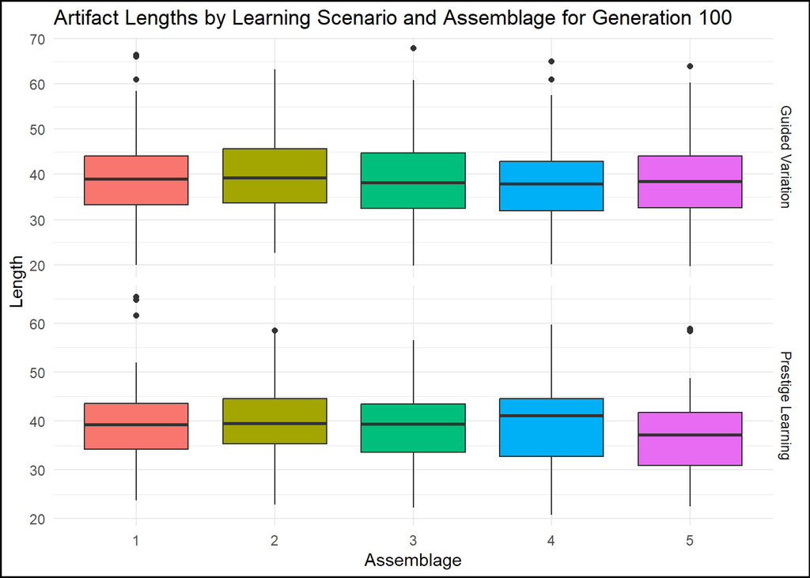

```r
ggplot(filtered_data2, aes(x=factor(Assemblage), y = Length, fill=factor(Assemblage))) +
  geom_boxplot() +
  facet_grid(rows=vars(Scenario), scales="free")+
  labs(title = paste("Artifact Lengths by Learning Scenario and Assemblage for Generation",Gen_Filter))+
  xlab("Assemblage")+
  theme_minimal()+
  theme(legend.position="none")+
      theme(plot.background = element_rect(color ="black", linewidth = 1))
```

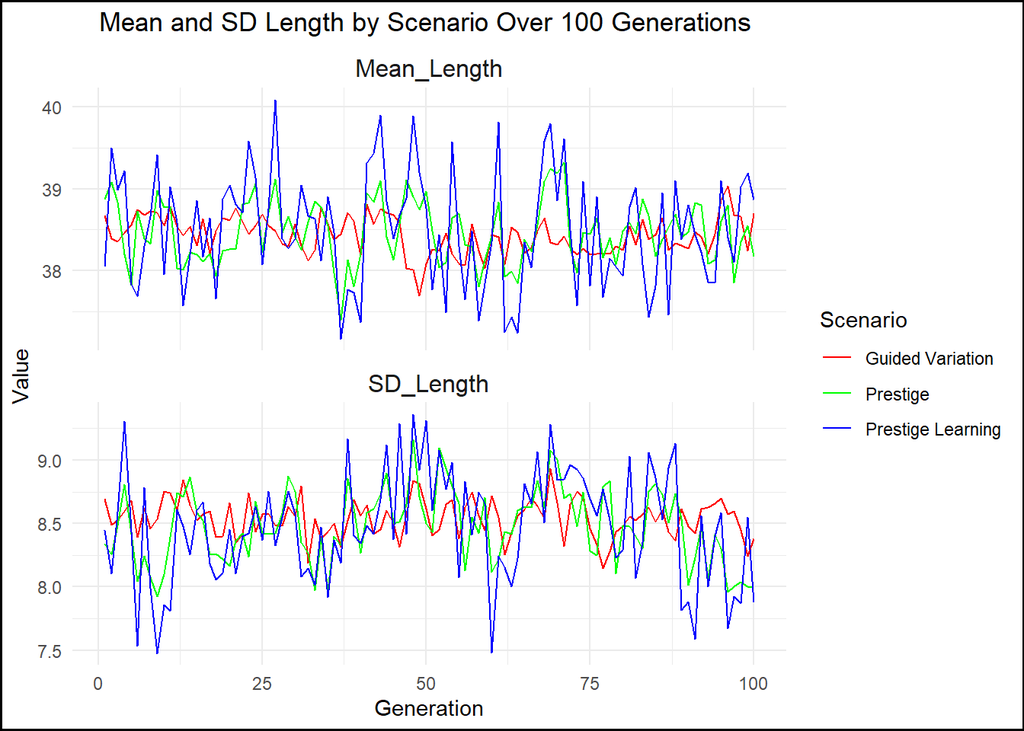

```r
# Calculate mean and standard deviation for each scenario and generation
generation_summary <- artifact_data %>%
  group_by(Scenario, Generation) %>%
  summarise(
    Mean_Length = mean(Length),
    SD_Length = sd(Length),
    .groups = 'drop'
  )

# Reshape the data to long format for plotting
generation_summary_long <- tidyr::pivot_longer(
  generation_summary,
  cols = c(Mean_Length, SD_Length),
  names_to = "Statistic",
  values_to = "Value"
)

# Plot the data by generation with separate facets for mean and SD
ggplot(generation_summary_long, aes(x = Generation, y = Value, color = Scenario)) +
  geom_line() +   # Add lines
  #geom_point(aes(shape = Scenario)) +     # Add points with shapes by Scenario
  facet_wrap(~ Statistic, scales = "free_y", ncol = 1) +  # Separate facets for mean and SD
  theme_minimal() +
  scale_color_manual(values = c("Guided Variation" = "red", "Prestige" = "green", "Prestige Learning" = "blue")) +
  scale_shape_manual(values = c("Guided Variation" = 17, "Prestige" = 15, "Prestige Learning" = 18)) +  # Shapes for scenarios
  labs(
    title = paste("Mean and SD Length by Scenario Over", max(generation_summary_long$Generation),"Generations "),
    x = "Generation",
    y = "Value",
    color = "Scenario",
    shape = "Scenario") +
  theme(strip.background = element_blank(),  # Remove facet strip background for a cleaner look
        strip.text.x = element_text(size = 12),  # Increase facet strip text size for readability
        plot.title = element_text(hjust = 0.5),
        plot.background = element_rect(color ="black", linewidth = 1))
```

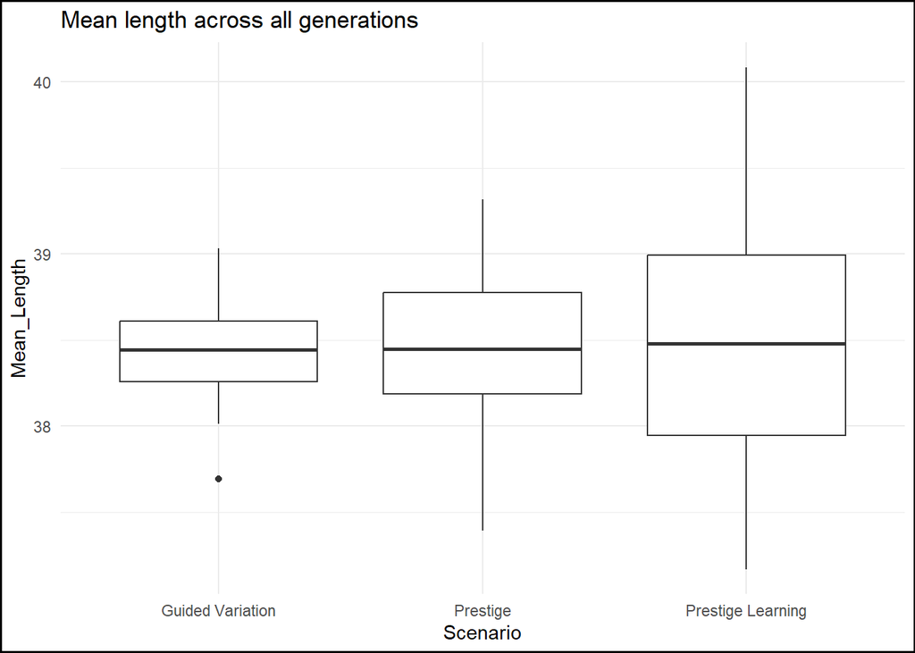

```r
ggplot(generation_summary, aes(x=Scenario, y = Mean_Length)) +
  geom_boxplot() +
  labs(title = "Mean length across all generations")+
  xlab("Scenario")+
  theme_minimal()+
      theme(plot.background = element_rect(color ="black", linewidth = 1))
```

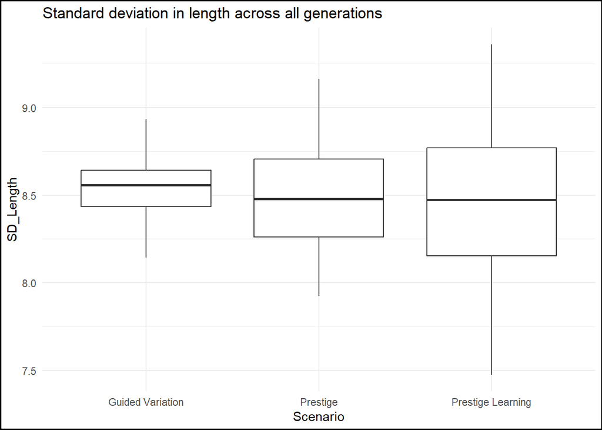

```r
ggplot(generation_summary, aes(x=Scenario, y = SD_Length)) +
  geom_boxplot() +
  labs(title = "Standard deviation in length across all generations")+
  xlab("Scenario")+
  theme_minimal()+
      theme(plot.background = element_rect(color ="black", linewidth = 1))
```

## Exploring variation of the mean (VOM), average variation (AV), and variation of variation (VOV) as potential predictors

- VOM is the standard deviation of the mean values for length
- AV is the mean of the standard deviations
- VOV is the standard deviation of the standard deviations

```r
artifact_stats <- artifact_data %>%
  group_by(Generation, Scenario, Assemblage) %>%
  summarize(
    Mean_Length = mean(Length),
    SD_Length = sd(Length)
  ) %>%
  ungroup() %>%
  group_by(Generation, Scenario) %>%
  summarize(
    VOM = sd(Mean_Length),# here VOM is the standard deviation of the mean values for length
    AV = mean(SD_Length), # AV is the mean of the standard deviations
    VOV = sd(SD_Length)   # VOV is the SD of the SDs
  )
# I'm mostly interested in comparing prestige learning with guided variation, so let's filter out the Prestige data
artifact_stats<-artifact_stats %>%
  filter(Scenario!="Prestige")

head(artifact_stats, 10)
```

```
## # A tibble: 10 × 5
## # Groups:   Generation [5]
##    Generation Scenario            VOM    AV   VOV
##         <dbl> <chr>             <dbl> <dbl> <dbl>
##  1          1 Guided Variation  0.416  8.70 0.234
##  2          1 Prestige Learning 0.521  8.44 0.368
##  3          2 Guided Variation  0.652  8.47 0.465
##  4          2 Prestige Learning 0.616  8.09 0.457
##  5          3 Guided Variation  1.10   8.48 0.326
##  6          3 Prestige Learning 1.08   8.54 0.483
##  7          4 Guided Variation  0.898  8.57 0.323
##  8          4 Prestige Learning 1.76   9.19 0.187
##  9          5 Guided Variation  0.749  8.66 0.516
## 10          5 Prestige Learning 1.45   8.29 1.07
```

## Plotting the data

There are a lot of different ways to consider displaying these data. Base R has a simple plot function that returns a nice biplot for each of the variables. However, the ggpairs function that we used with the simple model above also provides nice biplots along with density plots and correlation measures. Both this plot and a boxplot show how nicely VOM and VOV are separated while AV has considerable overlap. Finally, we can create a nice line chart that shows changes in these measurements over several generations.

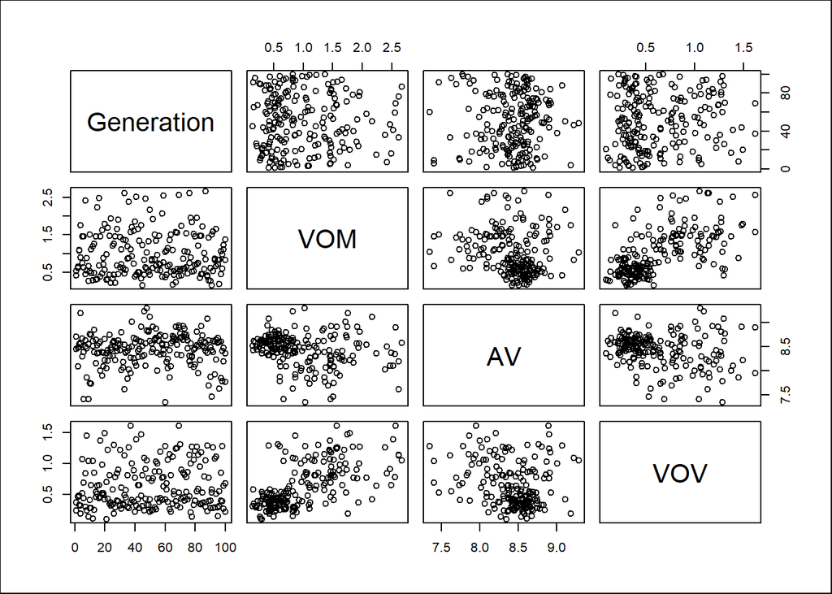

```r
# Let's plot to see our results. We can begin with a simple comparison of VOM, AV, and VOV, using the base r plot function that returns bi-plots of the three measures of variaiton

 artifact_stats %>% dplyr::select(VOM,AV,VOV) %>%
  plot(data=artifact_stats)
  box(col = "black", # Add box to plot
    which = "figure")
```

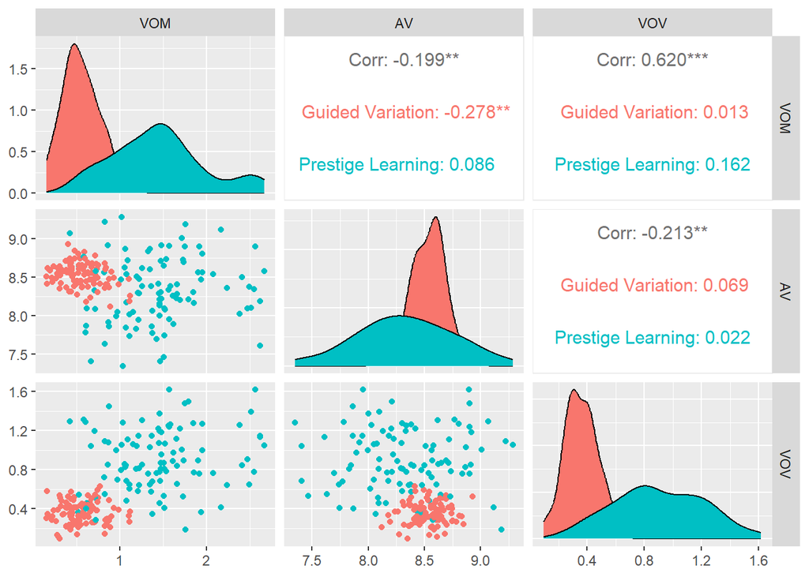

```r
ggpairs(artifact_stats, columns = 3:5, ggplot2::aes(color=Scenario), upper = list(continuous = wrap("cor", size = 4)))
```

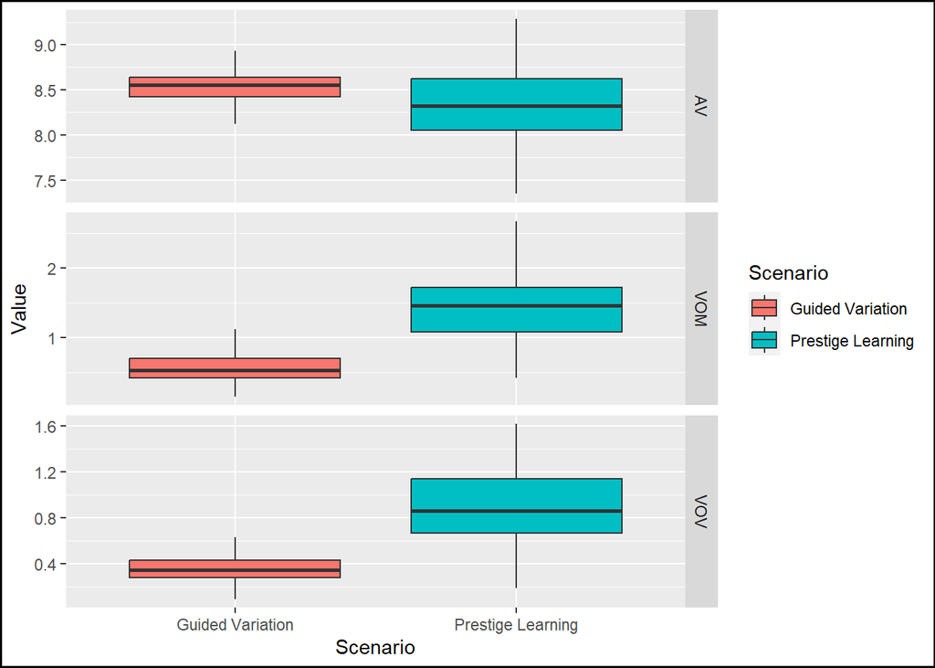

```r
#another view, but with a boxplot comparing the measures by learning scenario

  # First, we need to reshape the data to a long format
artifact_stats_long <- artifact_stats %>%
  gather(key = "Metric", value = "Value", VOM, AV, VOV)

ggplot(data=artifact_stats_long, aes(x=Scenario, y = Value, fill=Scenario))+
  geom_boxplot()+
  facet_grid(rows=vars(Metric), scales="free")+
      theme(plot.background = element_rect(color ="black", linewidth = 1))
```

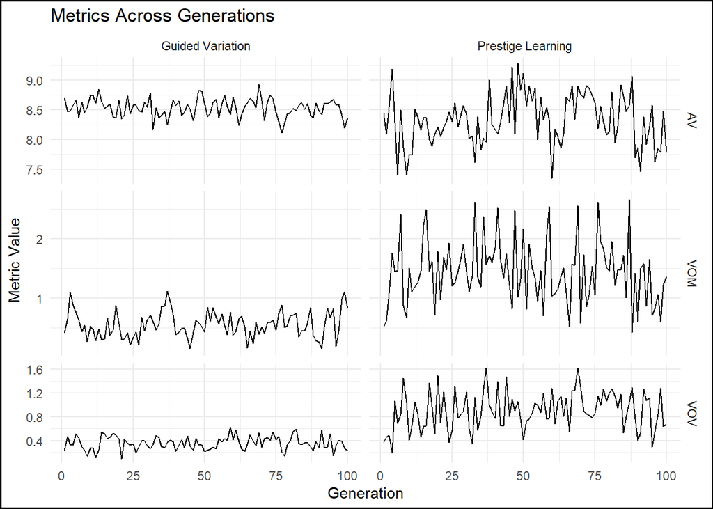

```r
# Now, plot the data using separate facets for each metric
ggplot(artifact_stats_long, aes(x = Generation, y = Value)) +
  geom_line() +
  facet_grid(Metric ~ Scenario, scales = "free_y", space = "free_y") +
  labs(
    title = "Metrics Across Generations",
    x = "Generation",
    y = "Metric Value"
  ) +
  theme_minimal()+
      theme(plot.background = element_rect(color ="black", linewidth = 1))
```